# Cad_Gis_Automation

## CAD to GIS Semi - Automation

**Created By: Data Team (PWA)**  
**Date : 20th September, 2022**

`Updated : 25th Dec, 2022`  
Technical Report By: Kevin Gathogo

## Introduction

Road data is usually huge,complex and aggregated from different specialised multi-disciplined contractors/sub-contractors. Irrespective of geometry, the submited data is varied in its characteristics, moreso the technical attributes . This is evident from the diverse scope, nature, location and materials involved in construction/Installation spanning from;

- Signals and Signage
  - Trafic and Directional Sign
  - Traffic control and management (ITS)
  - Road Markings
- Lighting
- Layouts - Civil Work and Pavement (Road Lines and Carriageway)
- Structures such as bridges and overpasses

Actually Qatar Traffic Control Manual is a 350 plus page document, heavy in content and details capturing roughly less than half of the PWA Roads database (Signages & Markings )

CAD to GIS conversion usually takes between 4-5 weeks depending on the complexity of the submitted road and the number of feature classes. Over time this has proven to be time-consuming.

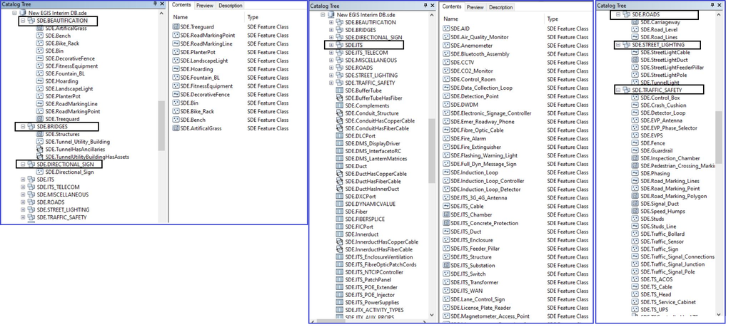

## Objective

These tools intend to:

- Semi-Automate Conversion of CAD data to GIS data format. It maps and append each layer of Cad to its respective feature class.
- Populate Primary/Common Attributes in all the feature classes.

#### NOTE:

**- The scope does not involve topological editing of Road lines and Carriageway polygonization.**  
**- It Overlaps with RFP1 - Automation.**  
**- Its NOT embedded in any application, apart from Arcmap has a script.**  
**- It enables a GIS Editor to focus on a soft QA/QC of the converted data, engage in minor edits, lessen the back and forth movement of from CAD to GIS during manual data extraction of individual features.**  
**-Increases accuracy and completeness of the gathered data/information from CAD**  
**-It saves time of the repetitive task such as appending CAD layers to different feature classes, Attribution etc.**  
**-User friendly, with few parameters to input to run.**  
**-Works well when data is compiled in the given AutoCAD template catering for both Standard and Non-Standard.*

Foristance if it takes a day to complete fully, a single asset such as traffic signs or streetlight pole (over 450 records in attribute table) or ducts, The tool greatly shorten that time, that in two to three day (Subject to nature of the project) you can have all assets in the gdb with Common Attributes saving on the numerous iterative geoprocessing operations.

*Below Code imports the necessary modules/packages necessary*

```python
#modules
import arcpy
import pandas as pd
import arcgis

from IPython.display import display
from arcgis.gis import GIS
```

*Define our environment in terms of the workspace*

```python
#Workspace
arcpy.env.workspace = r"D:/Drive/RPD/DN005-P01 IFC"
arcpy.env.overwriteOutput = True
```

*Create the necessary variable that will be our parameter for CAD to Geodatabase*

```python
workspace = r"D:/Drive/RPD/DN005-P01 IFC"
input_cad_dataset = workspace + "/PWA_CAD_Template_Standard_Non_Standard.dwg"
out_gdb_path = workspace + "/Roads_Interim_Database.gdb"
gdb_name = "/Roads_Interim_Database.gdb"

out_dataset_name = "ASBUILT"
out_dataset_name_pt = "ASBUILT_Point"
out_dataset_name_pl = "ASBUILT_Polyline"
out_dataset_name_pg = "ASBUILT_Polygon"
```

### CADToGeodatabase

- ASBUILT : - This is the ouput of our converted CAD to GIS in raw form (Point, Polyline, Polygon, Multipatch and Annotation)
- ASBUILT_Point : - From the point feature class in ASBUILT Dataset, the Layers inside are converted to individual point features
- ASBUILT_Polyline :- Similarly from polyline to individual layers of CAD
- ASBUILT_Polygon:- From Polygon to individual layers

The reason for the above is to act as:

- Backup to what will be appended later to various features classes in our schema
- To be read and be appended based on some defined dictionary partially guided by PWA Standards

*Below is a graphic snapshot of the discussed Datasets in a PWA Roads gdb schema.*

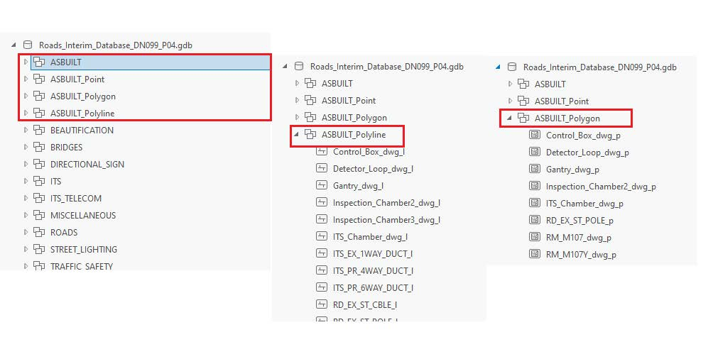

*CAdToGeodatabase geoprocessing syntax for creating the above datasets.*

```python
reference_scale = "1000"
spatial_reference = "QND_1995_Qatar_National_Grid"

# Create a file geodatabase for the feature dataset
# arcpy.CreateFileGDB_management(workspace, gdb_name)
# Execute CreateFeaturedataset

arcpy.CADToGeodatabase_conversion(input_cad_dataset, out_gdb_path, out_dataset_name, reference_scale)
arcpy.CADToGeodatabase_conversion(input_cad_dataset, out_gdb_path, out_dataset_name_pt, reference_scale)
arcpy.CADToGeodatabase_conversion(input_cad_dataset, out_gdb_path, out_dataset_name_pl, reference_scale)
arcpy.CADToGeodatabase_conversion(input_cad_dataset, out_gdb_path, out_dataset_name_pg, reference_scale)
```

Output

D:/Drive/RPD/DN005-P01 IFC/Roads_Interim_Database.gdb\ASBUILT_Polygon

Messages

Start Time: Tuesday, January 17, 2023 11:33:46 PM  
Succeeded at Tuesday, January 17, 2023 11:34:01 PM (Elapsed Time: 14.70 seconds)

## Extracting, Transforming and Loading

CAD to GIS Conversion can be looked at in the lens of an ETL process. Which is basically extracting data from one medium `AutoCAD` `.dwg` format and transforming it to a different data format (GIS format).  
Then Loading of the transformed data into a gdb or SDE.

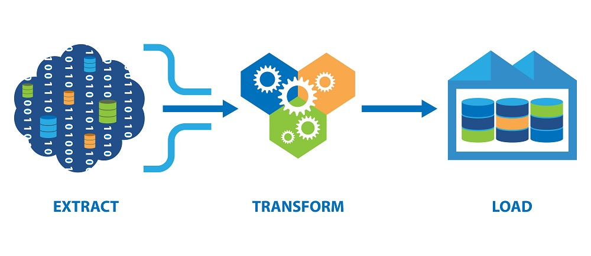

### ETL- Layers to Feature Class

```python
# defining the variables

arcpy.env.workspace = r"D:/Drive/RPD/DN005-P01 IFC/Roads_Interim_Database.gdb/"
featureclass_loc_pt = r"D:/Drive/RPD/DN005-P01 IFC/Roads_Interim_Database.gdb/ASBUILT_Point/"
featureclass_loc_pl = r"D:/Drive/RPD/DN005-P01 IFC/Roads_Interim_Database.gdb/ASBUILT_Polyline/"
featureclass_loc_pg = r"D:/Drive/RPD/DN005-P01 IFC/Roads_Interim_Database.gdb/ASBUILT_Polygon/"
```

```python
# Iterating the datasets, searching the ASBUILT_Point, ASBUILT_Polyline, ASBUILT_Polygon

datasets = arcpy.ListDatasets(feature_type='feature')
asbuilt_all = ['ASBUILT']
asbuilt = ['ASBUILT_Point', 'ASBUILT_Polyline', 'ASBUILT_Polygon']

for dt in datasets:
    if dt in asbuilt:
        for fc in arcpy.ListFeatureClasses(feature_dataset=dt):
            arcpy.DeleteFeatures_management(fc)
```

```python
#print(datasets)

for ds in datasets:
    if ds in asbuilt_all:
        for fc in arcpy.ListFeatureClasses(feature_dataset=ds):
            print(fc)
            if fc == "Polyline":
                dataf = pd.DataFrame.spatial.from_featureclass(fc)
                data_polyline = dataf.replace({'Layer': '0'}, 'zero')
                df_polyline = data_polyline['Layer'].unique()

            elif fc == "Point":
                dataf = pd.DataFrame.spatial.from_featureclass(fc)
                data_point = dataf.replace({'Layer': '0'}, 'zero_point')
                df_point = data_point['Layer'].unique()

            elif fc == "Polygon":
                dataf = pd.DataFrame.spatial.from_featureclass(fc)
                data_polygon = dataf.replace({'Layer': '0'}, 'zero_poly')
                df_polygon = data_polygon['Layer'].unique()
```

```
Point
Polyline
Polygon
MultiPatch
```

```python
df_polyline
```

```
array(['Detector_Loop_dwg', 'ITS_EX_1WAY_DUCT', 'RD_EX_ST_POLE', 'RM_M402_dwg', 'RD_PR_TS_SIGN_POST'], dtype=object)
```

```python
df_point
```

```
array(['ITS_EX_CHBR_ITS', 'RD_EX_ST_POLE', 'RD_PR_TS_SIGN_POST', 'Center_Line_dwg'], dtype=object)
```

```python
df_polygon
```

```
array(['Detector_Loop_dwg', 'RD_EX_ST_POLE', 'RM_M402_dwg', 'RD_PR_TS_SIGN_POST'], dtype=object)
```

```python
#Extracting Point features

for f in df_point:
    k = data_point.loc[data_point['Layer'] == f]
    k.spatial.to_featureclass (location=featureclass_loc_pt+f, overwrite=True)

    print(f)
```

[output not shown]

```
ITS_EX_CHBR_ITS
RD_EX_ST_POLE
RD_PR_TS_SIGN_POST
Center_Line_dwg
```

```python
# Extracting polylines

for f in df_polyline:
    k = data_polyline.loc[data_polyline['Layer'] == f]
    k.spatial.to_featureclass (location=featureclass_loc_pl+f+"_l", overwrite=True)
    print(f)
```

```
Detector_Loop_dwg
ITS_EX_1WAY_DUCT
RD_EX_ST_POLE
RM_M402_dwg
RD_PR_TS_SIGN_POST
```

```python
# Extracting polygons

for f in df_polygon:
    k = data_polygon.loc[data_polygon['Layer'] == f]
    k.spatial.to_featureclass (location=featureclass_loc_pg+f+"_p", overwrite=True)
    print(f)
```

```
Detector_Loop_dwg
RD_EX_ST_POLE
RM_M402_dwg
RD_PR_TS_SIGN_POST
```

### Appending Function

The below appending function takes layer name and check against pre-defined dictionary

```python
def appendingfunction(x):
    #Create FieldMappings object to manage merge output fields
    fieldMappings = arcpy.FieldMappings()

    # Add the target table to the field mappings class to set the schema
    fieldMappings.addTable(x)

    # Add input fields for the feature remarks into featureRemarks field that matches the
    # target dataset since each input dataset has a different field name for this info
    fldMap = arcpy.FieldMap()
    fldMap.addInputField(fc,"layer")

    # Set name of new output field "featureRemarks"
    featureRemarks = fldMap.outputField
    featureRemarks.name, featureRemarks.aliasName, featureRemarks.type = "FEATURE_REMARKS", "Remarks", "TEXT"
    fldMap.outputField = featureRemarks

    # Add output field to field mappings object
    fieldMappings.addFieldMap(fldMap)

    return(fieldMappings)
```

### Feature Dictionary (Roads) - Based Ashghal GIS Standard

The below **hard-coded** feature dictionary is borrowed heavily from PWA CAD/GIS data standard usefull to map CAD layers to features that exist in the PWA schemas (Interim/ 64). It has been **customised to include Non-Standard drawing** but with a bit of some task in AutoCAD.

##### Linear Features - 64 Asbuilts

*A dictionary function that act as a look up table for feature classes of* **LINE geometry** in the schema.

```python
def line_features(feature):

    features = {

        # =============================================
        # BRIDGES
        # _ __ __ __ __ __ __ __ __ __ __ __ __ __ __ _

        # =============================================
        # ITS_TELECOM
        "Structures_Line":["Structures_Line_dwg","Gantry_dwg"],
        "Conduit":["Conduit_dwg"],
        "CopperCable":["CopperCable_dwg"],
        "FiberCable":["FiberCable_dwg"],
        # _ __ __ __ __ __ __ __ __ __ __ __ __ __ __ _

        # =============================================
        # MISCELLANEOUS
        # _ __ __ __ __ __ __ __ __ __ __ __ __ __ __ _

        # =============================================
        # TRAFFIC_SAFETY
        "Road_Marking_Lines":["RD_EX_TS_RM_500","RD_EX_TS_RM_501","RD_EX_TS_RM_502","RD_EX_TS_RM_505","RD_EX_TS_RM_506","RD_PR_TS_RM_506",
                           "RD_EX_TS_RM_507","RD_EX_TS_RM_508","RD_EX_TS_RM_509","RD_EX_TS_RM_510","RD_EX_TS_RM_511","RD_EX_TS_RM_512",
                           "RD_EX_TS_RM_513","RD_EX_TS_RM_513Y","RD_EX_TS_RM_519","RD_EX_TS_RM_520","RD_EX_TS_RM_525","RD_EX_TS_RM_526",
                           "RD_EX_TS_RM_527","RD_EX_TS_RM_528","RD_EX_TS_RM_529","RD_EX_TS_RM_530","RD_EX_TS_RM_534","RD_PR_TS_RM_500",
                           "RD_PR_TS_RM_501","RD_PR_TS_RM_502","RD_PR_TS_RM_505","RD_PR_TS_RM_506","RD_PR_TS_RM_506","RD_PR_TS_RM_507",
                           "RD_PR_TS_RM_508","RD_PR_TS_RM_509","RD_PR_TS_RM_510","RD_PR_TS_RM_511","RD_PR_TS_RM_512","RD_PR_TS_RM_513",
                           "RD_PR_TS_RM_513Y","RD_PR_TS_RM_519","RD_PR_TS_RM_520","RD_PR_TS_RM_525","RD_PR_TS_RM_526","RD_PR_TS_RM_527",
                           "RD_PR_TS_RM_528","RD_PR_TS_RM_529","RD_PR_TS_RM_530","RD_PR_TS_RM_534","RD_MRK_LINE_506","RD_MRK_LINE_507",
                           "RD_MRK_LINE_511","RD_EX_TS_RM_M107","RD_EX_TS_RM_M126","RD_EX_TS_RM_M201","RD_EX_TS_RM_M346","RD_EX_TS_RM_M102",
                           "RD_EX_TS_RM_M601","RD_EX_TS_RM_M101","RD_EX_TS_RM_M108","RD_EX_TS_RM_M109","RD_EX_TS_RM_M113","RD_EX_TS_RM_M114",
                           "RD_EX_TS_RM_M115","RD_EX_TS_RM_M801","RD_EX_TS_RM_M400","RD_EX_TS_RM_M118","RD_EX_TS_RM_M116","RD_EX_TS_RM_M117",
                           "RD_EX_TS_RM_M110","RD_EX_TS_RM_M100","RD_EX_TS_RM_M110","RD_EX_TS_RM_M110","RD_EX_TS_RM_M110","RD_EX_TS_RM_M110",
                           "RD_PR_TS_RM_M601Y","RD_PR_TS_RM_M202","RD_PR_TS_RM_M402","RD_PR_TS_RM_M207","RD_PR_TS_RM_M407","RD_PR_TS_RM_M114",
                           "RD_PR_TS_RM_M110","RD_PR_TS_RM_M105","RD_PR_TS_RM_M106","RD_PR_TS_RM_M400","RD_PR_TS_RM_M102","RD_PR_TS_RM_M200",
                           "RD_PR_TS_RM_M104","RD_PR_TS_RM_M125","RD_PR_TS_RM_M129","RD_PR_TS_RM_M104Y","RD_PR_TS_RM_M128","RD_PR_TS_RM_M107",
                           "RD_PR_TS_RM_M107Y","RD_PR_TS_RM_M201","RD_PR_TS_RM_M408_6M","RM_500_dwg","RM_501_dwg","RM_502_dwg","RM_505_dwg",
                            "RM_506_dwg","RM_507_dwg","RM_508_dwg","RM_509_dwg","RM_510_dwg","RM_511_dwg","RM_512_dwg","RM_513_dwg","RM_513Y_dwg",
                            "RM_519_dwg","RM_520_dwg","RM_525_dwg","RM_526_dwg","RM_527_dwg","RM_528_dwg","RM_529_dwg","RM_530_dwg","RM_534_dwg"],


        "Studs_Line":["RD_EX_TS_STUDS","RD_PR_TS_STUDS","Studs_dwg"],
        "Vehicle_Restraint_System":["Vehicle_Restraint_System_dwg"],
        "Crash_Cushion":["Crash_Cushion_dwg","RD_EX_CONC_BARRIER","RD_EX_CRASH_CUSHION","RD_EX_SBAR_END","RD_EX_SBAR_TERM"],
        "Detector_Loop":["Detector_Loop_dwg","RD_EX_TS_DET_LOOP","RD_DE_TS_DET_LOOP"],
        "Fence":["Fence_dwg","RD_EX_FNCE","RD_PR_FNCE"],
        "Guardrail":["Guardrail_dwg","RD_EX_GRAIL","RD_PR_GRAIL"],
        "Phasing":["Phasing_dwg","Phase"],
        "Traffic_Signal_Connections":["Traffic_Signal_Connections_dwg"],
        "TS_Cable":["TS_Cable_Signal_Duct_1_dwg","TS_Cable_Signal_Duct_2_dwg","TS_Cable_Signal_Duct_3_dwg","TS_Cable_dwg","RD_EX_TS_DUCT","RD_PR_TS_DUCT",
                    "TS_Cable_dwg_uPVC_DUCT1","TS_Cable_dwg_uPVC_DUCT2","TS_Cable_dwg_uPVC_DUCT3"],
        # _ __ __ __ __ __ __ __ __ __ __ __ __ __ __ _

        # =============================================
        # BEAUTIFICATION
        "DecorativeFence":["DecorativeFence_dwg"],
        "Hoarding":["Hoarding_dwg"],
        "RoadMarkingLine":["RD_EX_TS_RM_500","RD_EX_TS_RM_501","RD_EX_TS_RM_502","RD_EX_TS_RM_505","RD_EX_TS_RM_506","RD_PR_TS_RM_506",
                           "RD_EX_TS_RM_507","RD_EX_TS_RM_508","RD_EX_TS_RM_509","RD_EX_TS_RM_510","RD_EX_TS_RM_511","RD_EX_TS_RM_512",
                           "RD_EX_TS_RM_513","RD_EX_TS_RM_513Y","RD_EX_TS_RM_519","RD_EX_TS_RM_520","RD_EX_TS_RM_525","RD_EX_TS_RM_526",
                           "RD_EX_TS_RM_527","RD_EX_TS_RM_528","RD_EX_TS_RM_529","RD_EX_TS_RM_530","RD_EX_TS_RM_534","RD_PR_TS_RM_500",
                           "RD_PR_TS_RM_501","RD_PR_TS_RM_502","RD_PR_TS_RM_505","RD_PR_TS_RM_506","RD_PR_TS_RM_506","RD_PR_TS_RM_507",
                           "RD_PR_TS_RM_508","RD_PR_TS_RM_509","RD_PR_TS_RM_510","RD_PR_TS_RM_511","RD_PR_TS_RM_512","RD_PR_TS_RM_513",
                           "RD_PR_TS_RM_513Y","RD_PR_TS_RM_519","RD_PR_TS_RM_520","RD_PR_TS_RM_525","RD_PR_TS_RM_526","RD_PR_TS_RM_527",
                           "RD_PR_TS_RM_528","RD_PR_TS_RM_529","RD_PR_TS_RM_530","RD_PR_TS_RM_534","RD_MRK_LINE_506","RD_MRK_LINE_507",
                           "RD_MRK_LINE_511","RD_EX_TS_RM_M107","RD_EX_TS_RM_M126","RD_EX_TS_RM_M201","RD_EX_TS_RM_M346","RD_EX_TS_RM_M102",
                           "RD_EX_TS_RM_M601","RD_EX_TS_RM_M101","RD_EX_TS_RM_M108","RD_EX_TS_RM_M109","RD_EX_TS_RM_M113","RD_EX_TS_RM_M114",
                           "RD_EX_TS_RM_M115","RD_EX_TS_RM_M801","RD_EX_TS_RM_M400","RD_EX_TS_RM_M118","RD_EX_TS_RM_M116","RD_EX_TS_RM_M117",
                           "RD_EX_TS_RM_M110","RD_EX_TS_RM_M100","RD_EX_TS_RM_M110","RD_EX_TS_RM_M110","RD_EX_TS_RM_M110","RD_EX_TS_RM_M110",
                           "RD_PR_TS_RM_M601Y","RD_PR_TS_RM_M202","RD_PR_TS_RM_M402","RD_PR_TS_RM_M207","RD_PR_TS_RM_M407","RD_PR_TS_RM_M114",
                           "RD_PR_TS_RM_M110","RD_PR_TS_RM_M105","RD_PR_TS_RM_M106","RD_PR_TS_RM_M400","RD_PR_TS_RM_M102","RD_PR_TS_RM_M200",
                           "RD_PR_TS_RM_M104","RD_PR_TS_RM_M125","RD_PR_TS_RM_M129","RD_PR_TS_RM_M104Y","RD_PR_TS_RM_M128","RD_PR_TS_RM_M107",
                           "RD_PR_TS_RM_M107Y","RD_PR_TS_RM_M201","RD_PR_TS_RM_M408_6M","RM_500_dwg","RM_501_dwg","RM_502_dwg","RM_505_dwg",
                            "RM_506_dwg","RM_507_dwg","RM_508_dwg","RM_509_dwg","RM_510_dwg","RM_511_dwg","RM_512_dwg","RM_513_dwg","RM_513Y_dwg",
                            "RM_519_dwg","RM_520_dwg","RM_525_dwg","RM_526_dwg","RM_527_dwg","RM_528_dwg","RM_529_dwg","RM_530_dwg","RM_534_dwg"],
        # _ __ __ __ __ __ __ __ __ __ __ __ __ __ __ _
```

```python
        # =============================================
        # STREET_LIGHTING
        "StreetLightCable":["StreetLightEarth_dwg","StreetLightCable_dwg","RD_EX_ST_10sq_mmCBLE","RD_EX_ST_16sq_mmCBLE","RD_EX_ST_25sq_mmCBLE","RD_EX_ST_35sq_mmCBLE","RD_EX_ST_CBLE",
                            "RD_PR_ST_10sq_mmCBLE","RD_PR_ST_16sq_mmCBLE","RD_PR_ST_25sq_mmCBLE","RD_PR_ST_35sq_mmCBLE","RD_PR_ST_CBLE",
                            "RD_EX_ST_ERTH","RD_PR_ST_ERTH","New_Sl_Cable_4m_25m","New_Sl_Cable_4m_16m","New_Sl_Cable_4m_35m"],
        # _ __ __ __ __ __ __ __ __ __ __ __ __ __ __ _

        # =============================================
        # ITS
        "Data_Collection_Loop":["Data_Collection_Loop_dwg"],
        "ITS_Duct":["ITS_Duct_dwg","ITS_EX_1WAY_DUCT","ITS_EX_2WAY_DUCT","ITS_EX_4WAY_DUCT","ITS_EX_6WAY_DUCT","ITS_EX_8WAY_DUCT",
                    "ITS_PR_1WAY_DUCT","ITS_PR_2WAY_DUCT","ITS_PR_4WAY_DUCT","ITS_PR_6WAY_DUCT","ITS_PR_8WAY_DUCT","ITS_EX_CROSSING_DUCT","UGN_PR_2WAY_DUCT",
                   "UGN_PR_2WAY_RGS_DUCT","UGN_PR_4WAY_RGS_DUCT","UGN_PR_6WAY_DUCT","UGN_PR_8WAY_DUCT","UGN_PR_JRC12","UGN_PR_JRC14"],

        "Induction_Loop":["Induction_Loop_dwg"],

        "ITS_Cable":["ITS_Cable_dwg","ITS_EX_1WAY_DUCT","ITS_EX_2WAY_DUCT","ITS_EX_4WAY_DUCT","ITS_EX_6WAY_DUCT","ITS_EX_8WAY_DUCT",
                    "ITS_PR_1WAY_DUCT","ITS_PR_2WAY_DUCT","ITS_PR_4WAY_DUCT","ITS_PR_6WAY_DUCT","ITS_PR_8WAY_DUCT"],

        "Fibre_Optic_Cable":["Fibre_Optic_Cable_dwg","ITS_EX_DUCT_FO","ITS_PR_DUCT_FO","RD_EX_DUCT_FO","RD_PR_DUCT_FO"],
        "RMS_FACable":["RMS_FACable_dwg"],
        "RMS_InductiveLoop":["RMS_InductiveLoop_dwg"],
        # _ __ __ __ __ __ __ __ __ __ __ __ __ __ __ _

        # =============================================
        #ROADS
        "Road_Lines":["Animal_Fence_dwg","Asphalt_Edge_dwg","Barrier_dwg","Center_Line_dwg","Concrete_Slope_Protection_dwg","Dropped_Kerb_dwg","Edge_Kerb_dwg","Fence_dwg",
                      "Flush_Kerb_dwg","Guardrail_dwg","Limit_of_Work_dwg","Null_dwg","Railway_dwg","Raised_Kerb_dwg","Riprap_dwg","Road_Edge_dwg","Wall_dwg","RD_EX_AFNCE",
                      "RD_PR_AFNCE","RD_EX_APED","RD_PR_APED","RD_EX_VBAR","RD_PR_VBAR","RD_EX_CNRL","RD_PR_CNRL","RD_EX_CSLPE","RD_PR_CSLPE","RD_EX_KBDD","RD_PR_KBDD",
                      "RD_EX_KBED","RD_PR_KBED","RD_EX_FNCE","RD_PR_FNCE","RD_EX_KBFL","RD_PR_KBFL","RD_EX_GRAIL","RD_PR_GRAIL","RD_EX_LOW","RD_PR_LOW","RD_EX_RAILWAY",
                      "RD_PR_RAILWAY","RD_EX_KBRD","RD_PR_KBRD","RD_EX_RRAP","RD_PR_RRAP","RD_EX_REDG","RD_PR_REDG","RD_EX_WALL","RD_PR_WALL"],

        "Road_Lines_1":["Animal_Fence_dwg","Asphalt_Edge_dwg","Barrier_dwg","Center_Line_dwg","Concrete_Slope_Protection_dwg","Dropped_Kerb_dwg","Edge_Kerb_dwg","Fence_dwg",
                      "Flush_Kerb_dwg","Guardrail_dwg","Limit_of_Work_dwg","Null_dwg","Railway_dwg","Raised_Kerb_dwg","Riprap_dwg","Road_Edge_dwg","Wall_dwg",
                        "RD_EX_AWAY","RD_PR_AWAY","RD_EX_ACRS","RD_PR_ACRS","RD_EX_AGRID","RD_PR_AGRID","RD_EX_BICYL","RD_PR_BICYL","RD_EX_CILND","RD_PR_CILND",
                        "RD_EX_CLMN","RD_PR_CLMN","RD_EX_CLVT","RD_PR_CLVT","RD_EX_MBK","RD_PR_MBK","RD_EX_FTPH","RD_PR_FTPH","TB_L_FACILITIES","TB_L_ FACILITIES",
                        "TB_L_GARBAGE_ BIN","TB_L_GARBAGE_BIN","TB_L_GRDN","TB_L_GRDN","RD_EX_ILOCK","RD_PR_ILOCK","RD_EX_JILND","RD_PR_JILND","RD_EX_MEDIAN",
                        "RD_PR_MEDIAN","RD_EX_PRKG","RD_PR_PRKG","RD_EX_PBAY","RD_PR_PBAY","RD_EX_TS_PBDG","RD_PR_TS_PBDG","RD_EX_PRAMP","RD_PR_PRAMP","RD_EX_SWAY",
                        "RD_PR_SWAY","RD_PBX","RD_F_PBX","RD_EX_RBTR","RD_PR_RBTR","RD_EX_SPTR","RD_PR_SPTR","RD_EX_RSLAB","RD_PR_RSLAB","RD_EX_SHLDR",
                        "RD_PR_SHLDR","RD_EX_STAIRS","RD_PR_STAIRS","RD_EX_SDITCH","RD_PR_SDITCH","RD_EX_VERGE","RD_PR_VERGE","RD_EX_WALL","RD_PR_WALL",
                        "RD_EX_CWAY","RD_PR_CWAY","RD_EX_BRDG","RD_EX_UPSS","RD_PR_BRDG","RD_PR_BRDG","RD_EX_NJB","RD_EX_OTHR"],

        "Carriageway_Line":["Accessway_dwg","Animal_Crossing_dwg","Animal_Grid_dwg","Bicycle_Lane_dwg","Carriageway_dwg","Central_Round_about_Island_dwg","Column_dwg",
                            "Culvert_dwg","Embankment_dwg","Footpath_dwg","Fountain_dwg","Garbage_Bin_dwg","Garden_dwg","Interlock_dwg","Junction_Island_dwg","Median_dwg",
                            "Null_dwg","Parking_dwg","Parking_Bay_dwg","Pedestrian_Footbridge_dwg","Pedestrian_Ramp_dwg","Pedestrian_Subway_dwg","Plant_Box_dwg","Road_Batter_dwg",
                            "Road_Separator_dwg","Road_Slab_dwg","Shoulder_dwg","Stairs_dwg","Swale_Ditch_dwg","Verge_dwg","Wall_dwg","RD_EX_AWAY","RD_PR_AWAY","RD_EX_ACRS",
                            "RD_PR_ACRS","RD_EX_AGRID","RD_PR_AGRID","RD_EX_BICYL","RD_PR_BICYL","RD_EX_CILND","RD_PR_CILND","RD_EX_CLMN","RD_PR_CLMN","RD_EX_CLVT","RD_PR_CLVT",
                            "RD_EX_MBK","RD_PR_MBK","RD_EX_FTPH","RD_PR_FTPH","TB_L_FACILITIES","TB_L_ FACILITIES","TB_L_GARBAGE_ BIN","TB_L_GARBAGE_BIN","TB_L_GRDN","TB_L_GRDN",
                            "RD_EX_ILOCK","RD_PR_ILOCK","RD_EX_JILND","RD_PR_JILND","RD_EX_MEDIAN","RD_PR_MEDIAN","RD_EX_PRKG","RD_PR_PRKG","RD_EX_PBAY","RD_PR_PBAY",
                            "RD_EX_TS_PBDG","RD_PR_TS_PBDG","RD_EX_PRAMP","RD_PR_PRAMP","RD_EX_SWAY","RD_PR_SWAY","RD_PBX","RD_F_PBX","RD_EX_RBTR","RD_PR_RBTR","RD_EX_SPTR",
                            "RD_PR_SPTR","RD_EX_RSLAB","RD_PR_RSLAB","RD_EX_SHLDR","RD_PR_SHLDR","RD_EX_STAIRS","RD_PR_STAIRS","RD_EX_SDITCH","RD_PR_SDITCH","RD_EX_VERGE",
                            "RD_PR_VERGE","RD_EX_WALL","RD_PR_WALL","RD_EX_CWAY","RD_PR_CWAY","RD_EX_BRDG","RD_EX_UPSS","RD_PR_BRDG","RD_PR_BRDG","RD_EX_OTHR","RD_EX_NJB",
                           "RD_EX_TS_RM_500","RD_EX_TS_RM_501","RD_EX_TS_RM_502","RD_EX_TS_RM_505","RD_EX_TS_RM_506","RD_PR_TS_RM_506",
                           "RD_EX_TS_RM_507","RD_EX_TS_RM_508","RD_EX_TS_RM_509","RD_EX_TS_RM_510","RD_EX_TS_RM_511","RD_EX_TS_RM_512",
                           "RD_EX_TS_RM_513","RD_EX_TS_RM_513Y","RD_EX_TS_RM_519","RD_EX_TS_RM_520","RD_EX_TS_RM_525","RD_EX_TS_RM_526",
                           "RD_EX_TS_RM_527","RD_EX_TS_RM_528","RD_EX_TS_RM_529","RD_EX_TS_RM_530","RD_EX_TS_RM_534","RD_PR_TS_RM_500",
                           "RD_PR_TS_RM_501","RD_PR_TS_RM_502","RD_PR_TS_RM_505","RD_PR_TS_RM_506","RD_PR_TS_RM_506","RD_PR_TS_RM_507",
                           "RD_PR_TS_RM_508","RD_PR_TS_RM_509","RD_PR_TS_RM_510","RD_PR_TS_RM_511","RD_PR_TS_RM_512","RD_PR_TS_RM_513",
                           "RD_PR_TS_RM_513Y","RD_PR_TS_RM_519","RD_PR_TS_RM_520","RD_PR_TS_RM_525","RD_PR_TS_RM_526","RD_PR_TS_RM_527",
                           "RD_PR_TS_RM_528","RD_PR_TS_RM_529","RD_PR_TS_RM_530","RD_PR_TS_RM_534","RD_MRK_LINE_506","RD_MRK_LINE_507",
                           "RD_MRK_LINE_511","RD_EX_TS_RM_M107","RD_EX_TS_RM_M126","RD_EX_TS_RM_M201","RD_EX_TS_RM_M346","RD_EX_TS_RM_M102",
                           "RD_EX_TS_RM_M601","RD_EX_TS_RM_M101","RD_EX_TS_RM_M108","RD_EX_TS_RM_M109","RD_EX_TS_RM_M113","RD_EX_TS_RM_M114",
                           "RD_EX_TS_RM_M115","RD_EX_TS_RM_M801","RD_EX_TS_RM_M400","RD_EX_TS_RM_M118","RD_EX_TS_RM_M116","RD_EX_TS_RM_M117",
                           "RD_EX_TS_RM_M110","RD_EX_TS_RM_M100","RD_EX_TS_RM_M110","RD_EX_TS_RM_M110","RD_EX_TS_RM_M110","RD_EX_TS_RM_M110",
                           "RD_PR_TS_RM_M601Y","RD_PR_TS_RM_M202","RD_PR_TS_RM_M402","RD_PR_TS_RM_M207","RD_PR_TS_RM_M407","RD_PR_TS_RM_M114",
                           "RD_PR_TS_RM_M110","RD_PR_TS_RM_M105","RD_PR_TS_RM_M106","RD_PR_TS_RM_M400","RD_PR_TS_RM_M102","RD_PR_TS_RM_M200",
                           "RD_PR_TS_RM_M104","RD_PR_TS_RM_M125","RD_PR_TS_RM_M129","RD_PR_TS_RM_M104Y","RD_PR_TS_RM_M128","RD_PR_TS_RM_M107",
                           "RD_PR_TS_RM_M107Y","RD_PR_TS_RM_M201","RD_PR_TS_RM_M408_6M","RM_500_dwg","RM_501_dwg","RM_502_dwg","RM_505_dwg",
                            "RM_506_dwg","RM_507_dwg","RM_508_dwg","RM_509_dwg","RM_510_dwg","RM_511_dwg","RM_512_dwg","RM_513_dwg","RM_513Y_dwg",
                            "RM_519_dwg","RM_520_dwg","RM_525_dwg","RM_526_dwg","RM_527_dwg","RM_528_dwg","RM_529_dwg","RM_530_dwg","RM_534_dwg"],
```

```python
        # _ __ __ __ __ __ __ __ __ __ __ __ __ __ __ _

               }


    return features.get(feature)
```

##### Point Features - 64 Asbuilts

*A mapping dictionary function that act as a look up table for feature classes of* **POINT geometry** in the schema.

```python
def point_features(feature):

    features = {

        #=============================================
        #BRIDGES
        "Tunnel_Utility_Building":["Tunnel_Utility_Building_dwg"],
        #_ __ __ __ __ __ __ __ __ __ __ __ __ __ __ _
        #=============================================
        #ITS_TELECOM

        "ITS_Pole":["ITS_Pole_dwg","ITS_PR_ENCL_PME","TS_PR_POLE_15M","TS_PR_POLE_6M","ITS_EX_ENCL_PME","ITS_EX_POLE_15m","TS_EX_POLE_6m","TS_PR_POLE","TS_EX_POLE"],
        "AnchorGuy":["AnchorGuy_dwg","A_AnchorGuy"],
        "CopperRepeater":["Conduit_dwg"],
        "DigitalCrossConnect":["DigitalCrossConnect_dwg"],
        "DigitalLoopCarrier":["DigitalLoopCarrier_dwg"],
        "FiberInterconnect":["FiberInterconnect_dwg"],
        "LoadCoil":["LoadCoil_dwg"],
        "MainDistributionFrame":["MainDistributionFrame_dwg"],
        "Multiplexer":["Multiplexer_dwg"],
        "OpticalRepeater":["OpticalRepeater_dwg"],
        "PatchPanel":["PatchPanel_dwg"],
        "PushBrace":["PushBrace_dwg"],
        "Riser":["Riser_dwg"],
        "SpliceClosure":["SpliceClosure_dwg"],
        "Splitter":["Splitter_dwg"],
        "Structure":["Structure_dwg"],
        "Terminal":["Terminal_dwg"],
        "Termination":["Termination_dwg"],
        #_ __ __ __ __ __ __ __ __ __ __ __ __ __ __ _
        #=============================================
        #MISCELLANEOUS

        "Solar_Panel":["Solar_Panel_dwg"],
        "Street_Sign":["Street_Sign_dwg","RD_EX_TS_SIGN_POST","RD_PR_TS_SIGN_POST","RD_EX_TS_SIGN","RD_PR_TS_SIGN","Traffic_Sign_dwg"],
        #_ __ __ __ __ __ __ __ __ __ __ __ __ __ __ _
        #=============================================
        #TRAFFIC_SAFETY

        "Control_Box":["Control_Box_dwg","RD_EX_TS_CTRL_BOX","RD_PR_TS_CTRL_BOX"],
        "EVP_Antenna":["EVP_Antenna_dwg","ITS_EX_ANTENNA","ITS_PR_ANTENNA"],
        "EVP_Phase_Selector":["EVP_Phase_Selector_dwg"],
        "TS_UPS":["TS_UPS_dwg","RD_EX_TS_SIGNAL_POST","RD_PR_TS_SIGNAL_POST"],
        "Traffic_Sensor":["Traffic_Sensor_dwg","A_Traffic_Sensor"],
        "Traffic_Signal_Pole":["Traffic_Signal_Pole_dwg","RD_EX_TS_SIGNAL_POST","RD_PR_TS_SIGNAL_POST","Push_Button_dwg"],
        "Traffic_Signal_Junction":["Traffic_Signal_Junction_dwg"],
        "Traffic_Sign":["Traffic_Sign_dwg","RD_EX_TS_SIGN_POST","RD_PR_TS_SIGN_POST","RD_EX_TS_SIGN","RD_PR_TS_SIGN"],
        "TS_ACOS":["TS_ACOS_dwg","RD_EX_TS_SIGNAL_POST","RD_PR_TS_SIGNAL_POST"],
        "TS_Head":["TS_Head_LEFT_Indicator_dwg","TS_Head_U_TURN_Indicator_dwg","TS_Head_2Aspect_Signal_Head_PEDESTRIAN_dwg","TS_Head_3Aspect_Signal_Head_VEHICLE_dwg","TS_Head_dwg","RD_EX_TS_SIGNAL_POST","RD_PR_TS_SIGNAL_POST"],
        "TS_Service_Cabinet":["TS_Service_Cabinet_dwg"],
        "Traffic_Bollard":["Traffic_Bollard_dwg","RD_EX_TS_BARL","RD_PR_TS_BARL"],
        "Studs":["Studs_dwg","RD_EX_TS_STUDS","RD_PR_TS_STUDS"],
        "Road_Marking_Point":["RD_EX_TS_RM_500","RD_EX_TS_RM_501","RD_EX_TS_RM_502","RD_EX_TS_RM_505","RD_EX_TS_RM_506","RD_PR_TS_RM_506",
                           "RD_EX_TS_RM_507","RD_EX_TS_RM_508","RD_EX_TS_RM_509","RD_EX_TS_RM_510","RD_EX_TS_RM_511","RD_EX_TS_RM_512",
                           "RD_EX_TS_RM_513","RD_EX_TS_RM_513Y","RD_EX_TS_RM_519","RD_EX_TS_RM_520","RD_EX_TS_RM_525","RD_EX_TS_RM_526",
                           "RD_EX_TS_RM_527","RD_EX_TS_RM_528","RD_EX_TS_RM_529","RD_EX_TS_RM_530","RD_EX_TS_RM_534","RD_PR_TS_RM_500",
                           "RD_PR_TS_RM_501","RD_PR_TS_RM_502","RD_PR_TS_RM_505","RD_PR_TS_RM_506","RD_PR_TS_RM_506","RD_PR_TS_RM_507",
                           "RD_PR_TS_RM_508","RD_PR_TS_RM_509","RD_PR_TS_RM_510","RD_PR_TS_RM_511","RD_PR_TS_RM_512","RD_PR_TS_RM_513",
                           "RD_PR_TS_RM_513Y","RD_PR_TS_RM_519","RD_PR_TS_RM_520","RD_PR_TS_RM_525","RD_PR_TS_RM_526","RD_PR_TS_RM_527",
                           "RD_PR_TS_RM_528","RD_PR_TS_RM_529","RD_PR_TS_RM_530","RD_PR_TS_RM_534","RD_MRK_LINE_506","RD_MRK_LINE_507",
                           "RD_MRK_LINE_511","RD_EX_TS_RM_M107","RD_EX_TS_RM_M126","RD_EX_TS_RM_M201","RD_EX_TS_RM_M346","RD_EX_TS_RM_M102",
                           "RD_EX_TS_RM_M601","RD_EX_TS_RM_M101","RD_EX_TS_RM_M108","RD_EX_TS_RM_M109","RD_EX_TS_RM_M113","RD_EX_TS_RM_M114",
                           "RD_EX_TS_RM_M115","RD_EX_TS_RM_M801","RD_EX_TS_RM_M400","RD_EX_TS_RM_M118","RD_EX_TS_RM_M116","RD_EX_TS_RM_M117",
                           "RD_EX_TS_RM_M110","RD_EX_TS_RM_M100","RD_EX_TS_RM_M110","RD_EX_TS_RM_M110","RD_EX_TS_RM_M110","RD_EX_TS_RM_M110",
                           "RD_PR_TS_RM_M601Y","RD_PR_TS_RM_M202","RD_PR_TS_RM_M402","RD_PR_TS_RM_M207","RD_PR_TS_RM_M407","RD_PR_TS_RM_M114",
                           "RD_PR_TS_RM_M110","RD_PR_TS_RM_M105","RD_PR_TS_RM_M106","RD_PR_TS_RM_M400","RD_PR_TS_RM_M102","RD_PR_TS_RM_M200",
                           "RD_PR_TS_RM_M104","RD_PR_TS_RM_M125","RD_PR_TS_RM_M129","RD_PR_TS_RM_M104Y","RD_PR_TS_RM_M128","RD_PR_TS_RM_M107",
                           "RD_PR_TS_RM_M107Y","RD_PR_TS_RM_M201","RD_PR_TS_RM_M408_6M","RM_500_dwg","RM_501_dwg","RM_502_dwg","RM_505_dwg",
                            "RM_506_dwg","RM_507_dwg","RM_508_dwg","RM_509_dwg","RM_510_dwg","RM_511_dwg","RM_512_dwg","RM_513_dwg","RM_513Y_dwg",
                            "RM_519_dwg","RM_520_dwg","RM_525_dwg","RM_526_dwg","RM_527_dwg","RM_528_dwg","RM_529_dwg","RM_530_dwg","RM_534_dwg",
                              "RM_503_dwg","RM_504_dwg","RM_514_dwg","RM_515_dwg","RM_516_dwg","RM_517_dwg","RM_518_dwg","RM_521_dwg","RM_522_dwg",
                              "RM_523_dwg","RM_524_dwg","RM_531_dwg","RM_532_dwg","RM_533_dwg"],

        "EVPS":["EVPS_dwg"],

        #_ __ __ __ __ __ __ __ __ __ __ __ __ __ __ _
        #=============================================
        #BEAUTIFICATION

        "LandscapeLight":["LandscapeLight_dwg"],
        "RoadMarkingPoint":["RD_EX_TS_RM_500","RD_EX_TS_RM_501","RD_EX_TS_RM_502","RD_EX_TS_RM_505","RD_EX_TS_RM_506","RD_PR_TS_RM_506",
                           "RD_EX_TS_RM_507","RD_EX_TS_RM_508","RD_EX_TS_RM_509","RD_EX_TS_RM_510","RD_EX_TS_RM_511","RD_EX_TS_RM_512",
                           "RD_EX_TS_RM_513","RD_EX_TS_RM_513Y","RD_EX_TS_RM_519","RD_EX_TS_RM_520","RD_EX_TS_RM_525","RD_EX_TS_RM_526",
                           "RD_EX_TS_RM_527","RD_EX_TS_RM_528","RD_EX_TS_RM_529","RD_EX_TS_RM_530","RD_EX_TS_RM_534","RD_PR_TS_RM_500",
                           "RD_PR_TS_RM_501","RD_PR_TS_RM_502","RD_PR_TS_RM_505","RD_PR_TS_RM_506","RD_PR_TS_RM_506","RD_PR_TS_RM_507",
                           "RD_PR_TS_RM_508","RD_PR_TS_RM_509","RD_PR_TS_RM_510","RD_PR_TS_RM_511","RD_PR_TS_RM_512","RD_PR_TS_RM_513",
                           "RD_PR_TS_RM_513Y","RD_PR_TS_RM_519","RD_PR_TS_RM_520","RD_PR_TS_RM_525","RD_PR_TS_RM_526","RD_PR_TS_RM_527",
                           "RD_PR_TS_RM_528","RD_PR_TS_RM_529","RD_PR_TS_RM_530","RD_PR_TS_RM_534","RD_MRK_LINE_506","RD_MRK_LINE_507",
                           "RD_MRK_LINE_511","RD_EX_TS_RM_M107","RD_EX_TS_RM_M126","RD_EX_TS_RM_M201","RD_EX_TS_RM_M346","RD_EX_TS_RM_M102",
                           "RD_EX_TS_RM_M601","RD_EX_TS_RM_M101","RD_EX_TS_RM_M108","RD_EX_TS_RM_M109","RD_EX_TS_RM_M113","RD_EX_TS_RM_M114",
                           "RD_EX_TS_RM_M115","RD_EX_TS_RM_M801","RD_EX_TS_RM_M400","RD_EX_TS_RM_M118","RD_EX_TS_RM_M116","RD_EX_TS_RM_M117",
                           "RD_EX_TS_RM_M110","RD_EX_TS_RM_M100","RD_EX_TS_RM_M110","RD_EX_TS_RM_M110","RD_EX_TS_RM_M110","RD_EX_TS_RM_M110",
                           "RD_PR_TS_RM_M601Y","RD_PR_TS_RM_M202","RD_PR_TS_RM_M402","RD_PR_TS_RM_M207","RD_PR_TS_RM_M407","RD_PR_TS_RM_M114",
                           "RD_PR_TS_RM_M110","RD_PR_TS_RM_M105","RD_PR_TS_RM_M106","RD_PR_TS_RM_M400","RD_PR_TS_RM_M102","RD_PR_TS_RM_M200",
                           "RD_PR_TS_RM_M104","RD_PR_TS_RM_M125","RD_PR_TS_RM_M129","RD_PR_TS_RM_M104Y","RD_PR_TS_RM_M128","RD_PR_TS_RM_M107",
                           "RD_PR_TS_RM_M107Y","RD_PR_TS_RM_M201","RD_PR_TS_RM_M408_6M"],
        "Bench":["Bench_dwg"],
        "PlanterPot":["PlanterPot_dwg"],
        "Bike_Rack":["Bike_Rack_dwg"],
        "FitnessEquipment":["FitnessEquipment_dwg"],
        "Bin":["Bin_dwg"],
        "Fountain_BL":["Fountain_BL_dwg"],
```

```python
        #_ __ __ __ __ __ __ __ __ __ __ __ __ __ __ _
        #=============================================
        #STREET_LIGHTING

        "StreetLightPole":["StreetLightPole_dwg","RD_EX_ST_POLE","RD_PR_ST_POLE","RD_EX_ST_POLE_10m","RD_PR_ST_POLE_10m","RD_EX_ST_POLE_8m","RD_PR_ST_POLE_8m","RD_EX_ST_POLE_12m","RD_PR_ST_POLE_12m",
                          "RD_EX_ST_POLE_20","RD_PR_ST_POLE_20m","RD_EX_ST_POLE_5m","RD_PR_ST_POLE_5m","RD_EX_ST_POLE_6m","RD_PR_ST_POLE_6m","RD_EX_ST_POLE_14m","RD_PR_ST_POLE_14m",
                          "RD_EX_ST_POLE_16","RD_PR_ST_POLE_16m","RD_EX_ST_POLE_18m","RD_PR_ST_POLE_18m","RD_EX_ST_POLE_25m","RD_PR_ST_POLE_25m","RD_EX_ST_POLE_30m","RD_PR_ST_POLE_30m"],

        "TunnelLight":["TunnelLight_dwg","RD_EX_ST_LIGHT","RD_PR_ST_LIGHT"],
        "StreetLightFeederPillar":["StreetLightFeederPillar_dwg","RD_EX_ST_FDPL","RD_PR_ST_FDPL"],
        #_ __ __ __ __ __ __ __ __ __ __ __ __ __ __ _
        #=============================================
        #ITS

        "VMS":["VMS_dwg"],
        "Weigh_Scale":["Weigh_Scale_dwg"],
        "Weigh_Station":["Weigh_Station_dwg"],
        "Weigh_In_Motion":["Weigh_In_Motion_dwg","ITS_EX_WIM_LOOP","ITS_PR_WIM_LOOP"],
        "ITS_3G_4G_Antenna":["ITS_3G_4G_Antenna_dwg","ITS_EX_ANTENNA","ITS_PR_ANTENNA"],
        "Detection_Point":["Detection_Point_dwg","ITS_EX_DZON","ITS_PR_DZON"],
        "Flashing_Warning_Light":["Flashing_Warning_Light_dwg","ITS_EX_FAWL","ITS_PR_FAWL"],
        "License_Plate_Reader":["License_Plate_Reader_dwg","ITS_EX_CCTV_PR","ITS_PR_CCTV_PR"],
        "OVDS_Alarm":["OVDS_Alarm_dwg","ITS_EX_ALRM_A","ITS_PR_ALRM_A","ITS_EX_ALRM_AV","ITS_PR_ALRM_AV"],
        "OVDS_Det_Assembly":["OVDS_Det_Assembly_dwg","ITS_EX_OVDS_AS","ITS_PR_OVDS_AS"],
        "Parking_Manage_Sign":["Parking_Manage_Sign_dwg","ITS_EX_PMS","ITS_PR_PMS"],
        "ITS_Transformer":["ITS_Transformer_dwg","ITS_EX_TRANS","ITS_PR_TRANS"],
        "Weather_Info_System":["Weather_Info_System_dwg","ITS_EX_RWIS_AS","ITS_PR_RWIS_AS"],
        "WIM_Controller":["WIM_Controller_dwg","A_WIM_Controller"],
        "ITS_WAN":["ITS_WAN_dwg","ITS_EX_ENCL_GME_SINGLE_WAN","ITS_PR_ENCL_GME_SINGLE_WAN"],
        "DWDM":["DWDM_dwg"],
        "Induction_Loop_Detector":["Induction_Loop_Detector_dwg"],
        "AID":["AID_dwg","ITS_EX_CCTV_AID","ITS_PR_CCTV_AID"],
        "Anemometer":["Anemometer_dwg"],
        "Air_Quality_Monitor":["Air_Quality_Monitor_dwg","ITS_EX_AQM_AS","ITS_PR_AQM_AS"],
        "CCTV":["CCTV_dwg","ITS_EX_CCTV_FIXD","ITS_PR_CCTV_FIXD", "ITS_EX_CCTV_PTZ","ITS_PR_CCTV_PTZ","ITS_EX_CCTV_AID","ITS_PR_CCTV_AID","ITS_PR_FEDR_PLR","ITS_PR_FEDR_PLR"],
        "CO2_Monitor":["CO2_Monitor_dwg"],
        "Control_Room":["Control_Room_dwg"],
        "Bluetooth_Assembly":["Bluetooth_Assembly_dwg","ITS_EX_BLUTH_DEV","ITS_PR_BLUTH_DEV"],
        "Full_Dyn_Message_Sign":["Full_Dyn_Message_Sign_dwg","ITS_EX_DMS","ITS_PR_DMS", "ITS_EX_RSDMS"],
        "Electronic_Signage_Controller":["Electronic_Signage_Controller_dwg","A_Electronic_Signage_Controller"],
        "Emer_Roadway_Phone":["Emer_Roadway_Phone_dwg"],
        "Fire_Alarm":["Fire_Alarm_dwg"],
        "Fire_Extinguisher":["Fire_Extinguisher_dwg"],
        "Induction_Loop_Controller":["Induction_Loop_Controller_dwg"],
        "ITS_Enclosure":["ITS_Enclosure_dwg","ITS_EX_ENCL_GME_SINGLE_WAN","ITS_PR_ENCL_GME_SINGLE_WAN", "ITS_EX_ENCL_GME_DOUBLE","ITS_EX_ENCL_GME_SINGLE_ITS"],
        "ITS_Feeder_Pillar":[ "ITS_Feeder_Pillar_dwg","ITS_PR_FEDR_PLR","ITS_PR_FEDR_PLR"],
        "ITS_Structure":["ITS_Structure_dwg"],
        "ITS_Switch":["ITS_Switch_dwg"],
        "Lane_Control_Sign":["Lane_Control_Sign_dwg","ITS_EX_LCS","ITS_PR_LCS"],
        "Magnetometer_Access_Point":["Magnetometer_Access_Point_dwg"],
        "Magnetometer_Detection_System":["Magnetometer_Detection_System_dwg"],
        "MVDS":["MVDS_dwg"],
        "OVDS_ControlBox":["OVDS_ControlBox_dwg"],
        "Public_Address_System":["Public_Address_System_dwg"],
        "Radio_Speaker":["Radio_Speaker_dwg"],
        "RMS":["RMS_dwg"],
        "RMS_RMController":["RMS_RMController_dwg"],
        "RVD":["RVD_dwg"],
        "Small_Dyn_Message_Sign":["Small_Dyn_Message_Sign_dwg","ITS_EX_SDMS","ITS_PR_SDMS"],
        "VIVD":["VIVD_dwg"],

        #_ __ __ __ __ __ __ __ __ __ __ __ __ __ __ _
        #=============================================
        #ROADS

        "Road_Level":["Road_Level_dwg","RD_EX_RLVL","RD_PR_RLVL","D_C_EX_GRND","D_C_FRL","RD_C_SPT_HGT"],
        #_ __ __ __ __ __ __ __ __ __ __ __ __ __ __ _
        #=============================================
        #DIRECTIONAL_SIGN

        "Directional_Sign":["Directional_Sign_dwg","RD_EX_TS_RDSN","RD_PR_TS_RDSN","ITS_EX_RSDMS"],
        #_ __ __ __ __ __ __ __ __ __ __ __ __ __ __ _

               }

    return features.get(feature)
```

##### Polygon Features - 64 Asbuilts

*A mapping dictionary function that act as a look-up table for feature classes of* **POLYGON geometry** in the schema.

```python
def Polygon_features(feature):

    features = {
        # =============================================
        # BRIDGES
        # _ __ __ __ __ __ __ __ __ __ __ __ __ __ __ _
        'Structures':["structure_dwg","Gantry_dwg"],

        # =============================================
        # ITS_TELECOM
        # _ __ __ __ __ __ __ __ __ __ __ __ __ __ __ _
        # =============================================
        # MISCELLANEOUS
        # _ __ __ __ __ __ __ __ __ __ __ __ __ __ __ _
        # =============================================
        # TRAFFIC_SAFETY
        # _ __ __ __ __ __ __ __ __ __ __ __ __ __ __ _
        "Inspection_Chamber":["Inspection_Chamber_dwg","Inspection_Chamber4_dwg","Inspection_Chamber_1dwg","Inspection_Chamber2_dwg","Inspection_Chamber3_dwg","RD_EX_TS_INCH","RD_PR_TS_INCH"],
        "Pedestrian_Crossing_Marking":["Pedestrian_Crossing_Marking_dwg","RD_PR_PRAMP","RD_EX_PRAMP","Pedestrian_Ramp_dwg"],
        "Signal_Duct":["Signal_Duct_dwg","RD_EX_TS_DUCT","RD_PR_TS_DUCT","TS_Cable_dwg_uPVC_DUCT1","TS_Cable_dwg_uPVC_DUCT2","TS_Cable_dwg_uPVC_DUCT3"],
        "Speed_Humps":["Speed_Humps_dwg","RD_PR_PRAMP","RD_PR_PRAMP","RD_EX_PRAMP","RD_EX_RSTL"],
        "Road_Marking_Polygon":["RD_EX_TS_RM_503","RD_PR_TS_RM_503","RD_EX_TS_RM_504","RD_PR_TS_RM_504","RD_EX_TS_RM_514","RD_PR_TS_RM_514",
                                 "RD_EX_TS_RM_515","RD_PR_TS_RM_515","RD_EX_TS_RM_516","RD_PR_TS_RM_516","RD_EX_TS_RM_517","RD_PR_TS_RM_517",
                                 "RD_EX_TS_RM_518","RD_PR_TS_RM_518","RD_EX_TS_RM_521","RD_PR_TS_RM_521","RD_EX_TS_RM_522","RD_PR_TS_RM_522",
                                 "RD_EX_TS_RM_523","RD_PR_TS_RM_523","RD_EX_TS_RM_524","RD_PR_TS_RM_524","RD_EX_TS_RM_531","RD_PR_TS_RM_531",
                                 "RD_EX_TS_RM_532","RD_PR_TS_RM_532","RD_EX_TS_RM_533","RD_PR_TS_RM_533", "RD_EX_TS_RM-M110","RD_EX_TS_RM-M117",
                                 "RD_EX_TS_RM-M111","RD_EX_TS_RM-M112","RD_EX_TS_RM-M113","RD_EX_TS_RM-M114","RD_EX_TS_RM-M115","RM_503_dwg",
                                "RM_504_dwg","RM_514_dwg","RM_515_dwg","RM_516_dwg","RM_517_dwg","RM_518_dwg","RM_521_dwg","RM_522_dwg","RM_523_dwg",
                                "RM_524_dwg","RM_531_dwg","RM_532_dwg","RM_533_dwg"],

        # =============================================
        # BEAUTIFICATION
        # _ __ __ __ __ __ __ __ __ __ __ __ __ __ __ _
        "ArtificalGrass":["ArtificalGrass_dwg"],
        "Treeguard":["Treeguard_dwg"],

        # =============================================
        # STREET_LIGHTING
        # _ __ __ __ __ __ __ __ __ __ __ __ __ __ __ _
        "StreetLightDuct":["StreetLightDuct_dwg","RD_EX_ST_DUCT","RD_PR_ST_DUCT","RD_EX_TS_DUCT","RD_PR_TS_DUCT"],


        # =============================================
        # ITS
        # _ __ __ __ __ __ __ __ __ __ __ __ __ __ __ _
        "ITS_Concrete_Protection":["ITS_Concrete_Protection_dwg"],
        "ITS_Substation":["ITS_Substation_dwg"],
        "ITS_Chamber":["ITS_Chamber_dwg","ITS_EX_CHBR_ITS","ITS_PR_CHBR_ITS"],


        # =============================================
        # ROADS
        # _ __ __ __ __ __ __ __ __ __ __ __ __ __ __ _
        #"Carriageway_Line":[""]
        "Carriageway":["Accessway_dwg","Animal_Crossing_dwg","Animal_Grid_dwg","Bicycle_Lane_dwg","Carriageway_dwg","Central_Round_about_Island_dwg","Column_dwg",
                       "Culvert_dwg","Embankment_dwg","Footpath_dwg","Fountain_dwg","Garbage_Bin_dwg","Garden_dwg","Interlock_dwg","Junction_Island_dwg","Median_dwg",
                       "Null_dwg","Parking_dwg","Parking_Bay_dwg","Pedestrian_Footbridge_dwg","Pedestrian_Ramp_dwg","Pedestrian_Subway_dwg","Plant_Box_dwg","Road_Batter_dwg",
                       "Road_Separator_dwg","Road_Slab_dwg","Shoulder_dwg","Stairs_dwg","Swale_Ditch_dwg","Verge_dwg","Wall_dwg","RD_EX_AWAY","RD_PR_AWAY","RD_EX_ACRS",
                       "RD_PR_ACRS","RD_EX_AGRID","RD_PR_AGRID","RD_EX_BICYL","RD_PR_BICYL","RD_EX_CILND","RD_PR_CILND","RD_EX_CLMN","RD_PR_CLMN","RD_EX_CLVT","RD_PR_CLVT",
                       "RD_EX_MBK","RD_PR_MBK","RD_EX_FTPH","RD_PR_FTPH","TB_L_FACILITIES","TB_L_ FACILITIES","TB_L_GARBAGE_ BIN","TB_L_GARBAGE_BIN","TB_L_GRDN","TB_L_GRDN",
                       "RD_EX_ILOCK","RD_PR_ILOCK","RD_EX_JILND","RD_PR_JILND","RD_EX_MEDIAN","RD_PR_MEDIAN","RD_EX_PRKG","RD_PR_PRKG","RD_EX_PBAY","RD_PR_PBAY",
                       "RD_EX_TS_PBDG","RD_PR_TS_PBDG","RD_EX_PRAMP","RD_PR_PRAMP","RD_EX_SWAY","RD_PR_SWAY","RD_PBX","RD_F_PBX","RD_EX_RBTR","RD_PR_RBTR","RD_EX_SPTR",
                       "RD_PR_SPTR","RD_EX_RSLAB","RD_PR_RSLAB","RD_EX_SHLDR","RD_PR_SHLDR","RD_EX_STAIRS","RD_PR_STAIRS","RD_EX_SDITCH","RD_PR_SDITCH","RD_EX_VERGE",
                       "RD_PR_VERGE","RD_EX_WALL","RD_PR_WALL","RD_EX_CWAY","RD_PR_CWAY","RD_EX_BRDG","RD_EX_UPSS","RD_PR_BRDG","RD_PR_BRDG","RD_EX_OTHR","RD_EX_NJB"],


        # =============================================
        # DIRECTIONAL_SIGN
        # _ __ __ __ __ __ __ __ __ __ __ __ __ __ __ _
            }

    return features.get(feature)
```

### Primary / Common Attributes (Roads) - Based Ashghal GIS Standard

**Primary / Common Attributes** a:- Attributes that are repeated (or a common) in almost all feature classes in PWA Roads fgdb/EGIS. These attribute can be populated during conversion and appended on all the various CAD layers file instantly. Why the name Primary attributes? This is because they are populated from our in-house data without any external or secondary data source. Primarily from our , Namely;

1. PROJECT_CODE
2. PROJECT_STATUS
3. PROJECT_TYPE
4. SOURCE_DATA_INPUT_FORMAT
5. DATA_INPUT_METHOD
6. METADATA
7. SOURCE_DEPT_SECTION_UNIT
8. OWNER
9. DATE_CREATED
10. EDITED_BY
11. LAST_UPDATED_DATE
12. FEATURE_LEVEL
13. PROJ_REF
14. CONTRACT_NO
15. FEATURE_STATUS

**Secondary Attributes** : - Attributes that we have to rely on data from secondary sources, e.g CGIS:

1. RD_ANAME
2. RD_ENAME
3. STREET_NO
4. ZONE_NO

**Technical Attributes** : - These are feature specific e,g Traffic sign code, streetlight pole height, Voltage etc.

```python
general_attribute = {"PROJECT_CODE":"IA 2017 C 141 G", "PROJECT_STATUS":"As Built","PROJECT_TYPE":"New","SOURCE_DATA_INPUT_FORMAT":"DWG",
                     "DATA_INPUT_METHOD":"Data Conversion", "METADATA":"No","SOURCE_DEPT_SECTION_UNIT":"Roads Projects", "OWNER":"Infrastructure Affairs",
                     "DATE_CREATED":"2023-01-01 00:00:00","EDITED_BY":"Kevin","LAST_UPDATED_DATE":"2023-01-03","FEATURE_LEVEL":"Ground_Level","PROJ_REF":"DN099-P05",
                     "CONTRACT_NO":"C/2019/133","FEATURE_STATUS":1}
```

```python
# Set local variables
outLocation = out_gdb_path
```

```python
def attributeUpdating(fc):

    start = time.process_time()

    field_names = [f.name for f in arcpy.ListFields(fc)]
    for key in general_attribute:
        if key in field_names:
            delimfield = arcpy.AddFieldDelimiters(fc, key)
            #print(key)
            value = general_attribute[key]
            #print(value)
            cursor = arcpy.da.UpdateCursor(fc, [key])
            for row in cursor:
                row[0] = value
                cursor.updateRow(row)
                del row
            del cursor
        #print(time.process_time() - start)
    return (fc)
```

```python
# ds_list = []
# fc_list_point = []
# fc_list_line = []
# fc_list_polygon = []

# datasets = arcpy.ListDatasets(feature_type='feature')
# for ds in datasets:
#     if ds not in ('ASBUILT', 'ASBUILT_Point', 'ASBUILT_Polyline', 'ASBUILT_Polygon'):
#         ds_list.append(ds)
#         ds_filter = ds
#         for fc in arcpy.ListFeatureClasses(feature_dataset=ds_filter, feature_type = "POINT"):
#             fc_list_point.append(fc)
#         for fc in arcpy.ListFeatureClasses(feature_dataset=ds_filter, feature_type = "POLYLINE"):
#             fc_list_line.append(fc)
#         for fc in arcpy.ListFeatureClasses(feature_dataset=ds_filter, feature_type = "POLYGON"):
#             fc_list_polygon.append(fc)
```

```python
schemaType = "NO_TEST"
fieldMappings = ""
subtype = ""

# Process:  Create a new empty feature class to append shapefiles into
# emptyFC = arcpy.CreateFeatureclass_management(outLocation, outName, "POLYGON",
#                                               "TOWNSSURVEY_POLY.shp")

#fc_list = []
datasets = arcpy.ListDatasets(feature_type='feature')
for ds in datasets:
    for fc in arcpy.ListFeatureClasses(feature_dataset=ds, feature_type = "POLYLINE"):
        print(fc)

        #1.Roadlines
        if fc[:-2] in line_features("Road_Lines"):
            arcpy.Append_management( fc,"Road_Lines", schemaType,appendingfunction("Road_Lines"), subtype)
            attributeUpdating("Road_Lines")

        if fc[:-2] in line_features("Road_Lines_1"):
            arcpy.Append_management( fc,"Road_Lines_1", schemaType,appendingfunction("Road_Lines_1"), subtype)
            attributeUpdating("Road_Lines_1")

        if fc[:-2] in line_features("Carriageway_Line"):
            arcpy.Append_management( fc,"Carriageway_Line", schemaType,appendingfunction("Carriageway_Line"), subtype)
            attributeUpdating("Carriageway_Line")

         #2.Road Marking Lines
        elif fc[:-2] in line_features("Road_Marking_Lines"):
            arcpy.Append_management( fc,"Road_Marking_Lines", schemaType, appendingfunction("Road_Marking_Lines"), subtype)
            attributeUpdating("Road_Marking_Lines")

        #3.Detector_Loop
        elif fc[:-2] in line_features("Detector_Loop"):
            arcpy.Append_management( fc,"Detector_Loop", schemaType,
                                    appendingfunction("Detector_Loop"), subtype)
            attributeUpdating("Detector_Loop")

        #4.StreetLight Cable
        elif fc[:-2] in line_features("StreetLightCable"):
            #print(fc)
            arcpy.Append_management( fc,"StreetLightCable", schemaType,
                                    appendingfunction("StreetLightCable"), subtype)
            attributeUpdating("StreetLightCable")

         #5.ITS_Duct
        elif fc[:-2] in line_features("ITS_Duct"):
            arcpy.Append_management( fc,"ITS_Duct", schemaType,
                                    appendingfunction("ITS_Duct"), subtype)
            attributeUpdating("ITS_Duct")

         #6.ITS_Fibre_Optic_Cable
        elif fc[:-2] in line_features("Fibre_Optic_Cable"):
            arcpy.Append_management( fc,"Fibre_Optic_Cable", schemaType,
                                    appendingfunction("Fibre_Optic_Cable"), subtype)
            attributeUpdating("Fibre_Optic_Cable")

        #7.A_ITS_Data_Collection_Loop
        elif fc[:-2] in line_features("Data_Collection_Loop"):
            arcpy.Append_management( fc,"Data_Collection_Loop", schemaType,
                                    appendingfunction("Data_Collection_Loop"), subtype)
            attributeUpdating("Data_Collection_Loop")

         #8.Traffic_Signal_Connections
        elif fc[:-2] in line_features("Traffic_Signal_Connections"):
            arcpy.Append_management( fc,"Traffic_Signal_Connections", schemaType,
                                    appendingfunction("Traffic_Signal_Connections"), subtype)
            attributeUpdating("Traffic_Signal_Connections")

         #9.PHASING
        elif fc[:-2] in line_features("Phasing"):
            arcpy.Append_management( fc,"Phasing", schemaType,
                                    appendingfunction("Phasing"), subtype)
            attributeUpdating("Phasing")

         #10.DIRECTIONAL_SIGNS_ANNOTATION
        elif fc[:-2] in line_features("Crash_Cushion"):
            arcpy.Append_management( fc,"Crash_Cushion", schemaType,
                                    appendingfunction("Crash_Cushion"), subtype)
            attributeUpdating("Crash_Cushion")

        elif fc[:-2] in line_features("RoadMarkingLine"):
            arcpy.Append_management( fc,"RoadMarkingLine", schemaType,
                                    appendingfunction2("RoadMarkingLine"), subtype)
            attributeUpdating("RoadMarkingLine")

        elif fc[:-2] in line_features("Fence"):
            arcpy.Append_management( fc,"Fence", schemaType,
                                    appendingfunction("Fence"), subtype)
            attributeUpdating("Fence")

        elif fc[:-2] in line_features("Guardrail"):
            arcpy.Append_management( fc,"Guardrail", schemaType,
                                    appendingfunction("Guardrail"), subtype)
            attributeUpdating("Guardrail")

        elif fc[:-2] in line_features("TS_Cable"):
            arcpy.Append_management( fc,"TS_Cable", schemaType,
                                    appendingfunction("TS_Cable"), subtype)
            attributeUpdating("TS_Cable")

        elif fc[:-2] in line_features("DecorativeFence"):
            arcpy.Append_management( fc,"DecorativeFence", schemaType,
                                    appendingfunction2("DecorativeFence"), subtype)
            attributeUpdating("DecorativeFence")

        elif fc[:-2] in line_features("Hoarding"):
            arcpy.Append_management( fc,"Hoarding", schemaType,
                                    appendingfunction2("Hoarding"), subtype)
            attributeUpdating("Hoarding")

        elif fc[:-2] in line_features("Induction_Loop"):
            arcpy.Append_management( fc,"Induction_Loop", schemaType,
                                    appendingfunction("Induction_Loop"), subtype)
            attributeUpdating("Induction_Loop")

        elif fc[:-2] in line_features("ITS_Cable"):
            arcpy.Append_management( fc,"ITS_Cable", schemaType,
                                    appendingfunction("ITS_Cable"), subtype)
            attributeUpdating("ITS_Cable")

        elif fc[:-2] in line_features("Fibre_Optic_Cable"):
            arcpy.Append_management( fc,"Fibre_Optic_Cable", schemaType,
                                    appendingfunction("Fibre_Optic_Cable"), subtype)
            attributeUpdating("Fibre_Optic_Cable")

        elif fc[:-2] in line_features("RMS_FACable"):
            arcpy.Append_management( fc,"RMS_FACable", schemaType,
                                    appendingfunction("RMS_FACable"), subtype)
            attributeUpdating("RMS_FACable")
```

```python
        elif fc[:-2] in line_features("RMS_InductiveLoop"):
            arcpy.Append_management( fc,"RMS_InductiveLoop", schemaType,
                                    appendingfunction("RMS_InductiveLoop"), subtype)
            attributeUpdating("RMS_InductiveLoop")

        elif fc[:-2] in line_features("Studs_Line"):
            arcpy.Append_management( fc,"Studs_Line", schemaType,
                                    appendingfunction("Studs_Line"), subtype)
            attributeUpdating("Studs_Line")

        elif fc[:-2] in line_features("Vehicle_Restraint_System"):
            arcpy.Append_management( fc,"Vehicle_Restraint_System", schemaType,
                                    appendingfunction("Vehicle_Restraint_System"), subtype)
            attributeUpdating("Vehicle_Restraint_System")

        elif fc[:-2] in line_features("RMS_InductiveLoop"):
            arcpy.Append_management( fc,"RMS_InductiveLoop", schemaType,
                                    appendingfunction("RMS_InductiveLoop"), subtype)
            attributeUpdating("RMS_InductiveLoop")

        elif fc[:-2] in line_features("Conduit"):
            arcpy.Append_management( fc,"Conduit", schemaType,
                                    appendingfunction("Conduit"), subtype)
            attributeUpdating("Conduit")

        elif fc[:-2] in line_features("CopperCable"):
            arcpy.Append_management( fc,"CopperCable", schemaType,
                                    appendingfunction("CopperCable"), subtype)
            attributeUpdating("CopperCable")

        elif fc[:-2] in line_features("FiberCable"):
            arcpy.Append_management( fc,"FiberCable", schemaType,
                                    appendingfunction("FiberCable"), subtype)
            attributeUpdating("FiberCable")


    for fc in arcpy.ListFeatureClasses(feature_dataset=ds, feature_type = "POINT"):
        print(fc)

        #1.Road level
        if fc in point_features("Road_Level"):
            arcpy.Append_management( fc,"Road_Level", schemaType,appendingfunction("Road_Level"), subtype)
            attributeUpdating("Road_Level")

         #2.Studs
        elif fc in point_features("Studs"):
            arcpy.Append_management( fc,"Studs", schemaType,appendingfunction("Studs"), subtype)
            attributeUpdating("Studs")

        #3.Traffic Sign
        elif fc in point_features("Traffic_Sign"):
            arcpy.Append_management( fc,"Traffic_Sign", schemaType,appendingfunction("Traffic_Sign"), subtype)
            attributeUpdating("Traffic_Sign")

        #4.Traffic Signal Pole
        elif fc in point_features("Traffic_Signal_Pole"):
            arcpy.Append_management( fc,"Traffic_Signal_Pole", schemaType,appendingfunction("Traffic_Signal_Pole"), subtype)
            attributeUpdating("Traffic_Signal_Pole")

         #5.StreetLight Pole
        elif fc in point_features("StreetLightPole"):
            arcpy.Append_management( fc,"StreetLightPole", schemaType, appendingfunction("StreetLightPole"), subtype)
            attributeUpdating("StreetLightPole")

         #6.Tunnel light
        elif fc in point_features("TunnelLight"):
            arcpy.Append_management( fc,"TunnelLight", schemaType,appendingfunction("TunnelLight"), subtype)
            attributeUpdating("TunnelLight")

        #7.Directional_Sign
        elif fc in point_features("Directional_Sign"):
            arcpy.Append_management( fc,"Directional_Sign", schemaType, appendingfunction("Directional_Sign"), subtype)
#             attributeUpdating("Directional_Sign")

         #8.Traffic_Signal_Connections
        elif fc in point_features("ITS_Feeder_Pillar"):
            arcpy.Append_management( fc,"ITS_Feeder_Pillar", schemaType,appendingfunction("ITS_Feeder_Pillar"), subtype)
            attributeUpdating("ITS_Feeder_Pillar")


         #10.A_ITS_Pole
        elif fc in point_features ("ITS_Pole"):
            arcpy.Append_management( fc,"ITS_Pole", schemaType,appendingfunction("ITS_Pole"), subtype)
            attributeUpdating("ITS_Pole")

        elif fc in point_features ("VMS"):
            arcpy.Append_management( fc,"VMS", schemaType,appendingfunction2("VMS"), subtype)
            attributeUpdating("VMS")

        elif fc in point_features ("Weigh_Scale"):
            arcpy.Append_management( fc,"Weigh_Scale", schemaType,appendingfunction("Weigh_Scale"), subtype)
            attributeUpdating("Weigh_Scale")

        elif fc in point_features ("Weigh_Station"):
            arcpy.Append_management( fc,"Weigh_Station", schemaType,appendingfunction("Weigh_Station"), subtype)
            attributeUpdating("Weigh_Station")

        elif fc in point_features ("Weigh_In_Motion"):
            arcpy.Append_management( fc,"Weigh_In_Motion", schemaType,appendingfunction("Weigh_In_Motion"), subtype)
            attributeUpdating("Weigh_In_Motion")

        elif fc in point_features ("Weigh_In_Motion"):
            arcpy.Append_management( fc,"Weigh_In_Motion", schemaType,appendingfunction("Weigh_In_Motion"), subtype)
            attributeUpdating("Weigh_In_Motion")

        elif fc in point_features ("ITS_3G_4G_Antenna"):
            arcpy.Append_management( fc,"ITS_3G_4G_Antenna", schemaType,appendingfunction("ITS_3G_4G_Antenna"), subtype)
            attributeUpdating("ITS_3G_4G_Antenna")

        elif fc in point_features ("Flashing_Warning_Light"):
            arcpy.Append_management( fc,"Flashing_Warning_Light", schemaType,appendingfunction("Flashing_Warning_Light"), subtype)
            attributeUpdating("Flashing_Warning_Light")

        elif fc in point_features ("License_Plate_Reader"):
            arcpy.Append_management( fc,"License_Plate_Reader", schemaType,appendingfunction("License_Plate_Reader"), subtype)
            attributeUpdating("License_Plate_Reader")

        elif fc in point_features ("OVDS_Alarm"):
            arcpy.Append_management( fc,"OVDS_Alarm", schemaType,appendingfunction("OVDS_Alarm"), subtype)
            attributeUpdating("OVDS_Alarm")
```

```python
        elif fc in point_features ("OVDS_Det_Assembly"):
            arcpy.Append_management( fc,"OVDS_Det_Assembly", schemaType,appendingfunction("OVDS_Det_Assembly"), subtype)
            attributeUpdating("OVDS_Det_Assembly")

        elif fc in point_features ("Parking_Manage_Sign"):
            arcpy.Append_management( fc,"Parking_Manage_Sign", schemaType,appendingfunction("Parking_Manage_Sign"), subtype)
            attributeUpdating("Parking_Manage_Sign")

        elif fc in point_features ("ITS_Transformer"):
            arcpy.Append_management( fc,"ITS_Transformer", schemaType,appendingfunction("ITS_Transformer"), subtype)
            attributeUpdating("ITS_Transformer")

        elif fc in point_features ("Weather_Info_System"):
            arcpy.Append_management( fc,"Weather_Info_System", schemaType,appendingfunction("Weather_Info_System"), subtype)
            attributeUpdating("Weather_Info_System")

        elif fc in point_features ("ITS_WAN"):
            arcpy.Append_management( fc,"ITS_WAN", schemaType,appendingfunction2("ITS_WAN"), subtype)

        elif fc in point_features ("DWDM"):
            arcpy.Append_management( fc,"DWDM", schemaType,appendingfunction("DWDM"), subtype)
            attributeUpdating("DWDM")

        elif fc in point_features ("Induction_Loop_Detector"):
            arcpy.Append_management( fc,"Induction_Loop_Detector", schemaType,appendingfunction("Induction_Loop_Detector"), subtype)
            attributeUpdating("Induction_Loop_Detector")

        elif fc in point_features ("AID"):
            arcpy.Append_management( fc,"AID", schemaType,appendingfunction("AID"), subtype)
            attributeUpdating("AID")

        elif fc in point_features ("Anemometer"):
            arcpy.Append_management( fc,"Anemometer", schemaType,appendingfunction("Anemometer"), subtype)
            attributeUpdating("Anemometer")

        elif fc in point_features ("Air_Quality_Monitor"):
            arcpy.Append_management( fc,"Air_Quality_Monitor", schemaType,appendingfunction("Air_Quality_Monitor"), subtype)
            attributeUpdating("Air_Quality_Monitor")

        elif fc in point_features ("CCTV"):
            arcpy.Append_management( fc,"CCTV", schemaType,appendingfunction("CCTV"), subtype)
            attributeUpdating("CCTV")

        elif fc in point_features ("CO2_Monitor"):
            arcpy.Append_management( fc,"CO2_Monitor", schemaType,appendingfunction("CO2_Monitor"), subtype)
            attributeUpdating("CO2_Monitor")

        elif fc in point_features ("Control_Room"):
            arcpy.Append_management( fc,"Control_Room", schemaType,appendingfunction("Control_Room"), subtype)
            attributeUpdating("Control_Room")

        elif fc in point_features ("Bluetooth_Assembly"):
            arcpy.Append_management( fc,"Bluetooth_Assembly", schemaType,appendingfunction("Bluetooth_Assembly"), subtype)
            attributeUpdating("Bluetooth_Assembly")

        elif fc in point_features ("Full_Dyn_Message_Sign"):
            arcpy.Append_management( fc,"Full_Dyn_Message_Sign", schemaType,appendingfunction("Full_Dyn_Message_Sign"), subtype)
            attributeUpdating("Full_Dyn_Message_Sign")

        elif fc in point_features ("Electronic_Signage_Controller"):
            arcpy.Append_management( fc,"Electronic_Signage_Controller", schemaType,appendingfunction("Electronic_Signage_Controller"), subtype)
            attributeUpdating("Electronic_Signage_Controller")

        elif fc in point_features ("Emer_Roadway_Phone"):
            arcpy.Append_management( fc,"Emer_Roadway_Phone", schemaType,appendingfunction("Emer_Roadway_Phone"), subtype)
            attributeUpdating("Emer_Roadway_Phone")

        elif fc in point_features ("Fire_Alarm"):
            arcpy.Append_management( fc,"Fire_Alarm", schemaType,appendingfunction("Fire_Alarm"), subtype)
            attributeUpdating("Fire_Alarm")

        elif fc in point_features ("Fire_Extinguisher"):
            arcpy.Append_management( fc,"Fire_Extinguisher", schemaType,appendingfunction("Fire_Extinguisher"), subtype)
            attributeUpdating("Fire_Extinguisher")

        elif fc in point_features ("Induction_Loop_Controller"):
            arcpy.Append_management( fc,"Induction_Loop_Controller", schemaType,appendingfunction("Induction_Loop_Controller"), subtype)
            attributeUpdating ("Induction_Loop_Controller")

        elif fc in point_features ("ITS_Enclosure"):
            arcpy.Append_management( fc,"ITS_Enclosure", schemaType,appendingfunction("ITS_Enclosure"), subtype)
            attributeUpdating("ITS_Enclosure")

        elif fc in point_features ("ITS_Structure"):
            arcpy.Append_management( fc,"ITS_Structure", schemaType,appendingfunction("ITS_Structure"), subtype)
            attributeUpdating("ITS_Structure")

        elif fc in point_features ("ITS_Switch"):
            arcpy.Append_management( fc,"ITS_Switch", schemaType,appendingfunction("ITS_Switch"), subtype)
            attributeUpdating("ITS_Switch")

        elif fc in point_features ("Lane_Control_Sign"):
            arcpy.Append_management( fc,"Lane_Control_Sign", schemaType,appendingfunction("Lane_Control_Sign"), subtype)
            attributeUpdating("Lane_Control_Sign")

        elif fc in point_features ("Magnetometer_Access_Point"):
            arcpy.Append_management( fc,"Magnetometer_Access_Point", schemaType,appendingfunction("Magnetometer_Access_Point"), subtype)
            attributeUpdating("Magnetometer_Access_Point")

        elif fc in point_features ("Magnetometer_Detection_System"):
            arcpy.Append_management( fc,"Magnetometer_Detection_System", schemaType,appendingfunction("Magnetometer_Detection_System"), subtype)
            attributeUpdating("Magnetometer_Detection_System")

        elif fc in point_features ("MVDS"):
            arcpy.Append_management( fc,"MVDS", schemaType,appendingfunction("MVDS"), subtype)
            attributeUpdating("MVDS")

        elif fc in point_features ("OVDS_ControlBox"):
            arcpy.Append_management( fc,"OVDS_ControlBox", schemaType,appendingfunction("OVDS_ControlBox"), subtype)
            attributeUpdating("OVDS_ControlBox")
```

```python
        elif fc in point_features ("Public_Address_System"):
            arcpy.Append_management( fc,"Public_Address_System", schemaType,appendingfunction("Public_Address_System"), subtype)
            attributeUpdating("Public_Address_System")

        elif fc in point_features ("Radio_Speaker"):
            arcpy.Append_management( fc,"Radio_Speaker", schemaType,appendingfunction("Radio_Speaker"), subtype)
            attributeUpdating("Radio_Speaker")

        elif fc in point_features ("RMS"):
            arcpy.Append_management( fc,"RMS", schemaType,appendingfunction("RMS"), subtype)
            attributeUpdating("RMS")

        elif fc in point_features ("RMS_RMController"):
            arcpy.Append_management( fc,"RMS_RMController", schemaType,appendingfunction("RMS_RMController"), subtype)
            attributeUpdating("RMS_RMController")

        elif fc in point_features ("RVD"):
            arcpy.Append_management( fc,"RVD", schemaType,appendingfunction("RVD"), subtype)
            attributeUpdating("RVD")

        elif fc in point_features ("Small_Dyn_Message_Sign"):
            arcpy.Append_management( fc,"Small_Dyn_Message_Sign", schemaType,appendingfunction("Small_Dyn_Message_Sign"), subtype)
            attributeUpdating("Small_Dyn_Message_Sign")

        elif fc in point_features ("VIVD"):
            arcpy.Append_management( fc,"VIVD", schemaType,appendingfunction("VIVD"), subtype)
            attributeUpdating("VIVD")

        elif fc in point_features ("LandscapeLight"):
            arcpy.Append_management( fc,"LandscapeLight", schemaType,appendingfunction("LandscapeLight"), subtype)
            attributeUpdating("LandscapeLight")

        elif fc in point_features ("RoadMarkingPoint"):
            arcpy.Append_management( fc,"RoadMarkingPoint", schemaType,appendingfunction("RoadMarkingPoint"), subtype)
            attributeUpdating("RoadMarkingPoint")

        elif fc in point_features ("StreetLightFeederPillar"):
            arcpy.Append_management( fc,"StreetLightFeederPillar", schemaType,appendingfunction("StreetLightFeederPillar"), subtype)
            attributeUpdating("StreetLightFeederPillar")

        elif fc in point_features ("Fountain_BL"):
            arcpy.Append_management( fc,"Fountain_BL", schemaType,appendingfunction2("Fountain_BL"), subtype)
            attributeUpdating("StreetLightFeederPillar")

        elif fc in point_features ("Bin"):
            arcpy.Append_management( fc,"Bin", schemaType,appendingfunction2("Bin"), subtype)
            attributeUpdating("StreetLightFeederPillar")

        elif fc in point_features ("FitnessEquipment"):
            arcpy.Append_management( fc,"FitnessEquipment", schemaType,appendingfunction2("FitnessEquipment"), subtype)
            attributeUpdating("FitnessEquipment")

        elif fc in point_features ("Bike_Rack"):
            arcpy.Append_management( fc,"Bike_Rack", schemaType,appendingfunction2("Bike_Rack"), subtype)
            attributeUpdating("Bike_Rack")

        elif fc in point_features ("PlanterPot"):
            arcpy.Append_management( fc,"PlanterPot", schemaType, appendingfunction2("PlanterPot"), subtype)
            attributeUpdating("PlanterPot")

        elif fc in point_features ("Bench"):
            arcpy.Append_management( fc,"Bench", schemaType,appendingfunction2("Bench"), subtype)
            attributeUpdating("Bench")

        elif fc in point_features ("LandscapeLight"):
            arcpy.Append_management( fc,"LandscapeLight", schemaType,appendingfunction2("LandscapeLight"), subtype)
            attributeUpdating("LandscapeLight")

        elif fc in point_features ("EVPS"):
            arcpy.Append_management( fc,"EVPS", schemaType,appendingfunction("EVPS"), subtype)
            attributeUpdating("EVPS")

        elif fc in point_features ("Traffic_Bollard"):
            arcpy.Append_management( fc,"Traffic_Bollard", schemaType,appendingfunction("Traffic_Bollard"), subtype)
            attributeUpdating("Traffic_Bollard")

        elif fc in point_features ("TS_Service_Cabinet"):
            arcpy.Append_management( fc,"TS_Service_Cabinet", schemaType,appendingfunction("TS_Service_Cabinet"), subtype)
            attributeUpdating("TS_Service_Cabinet")

        elif fc in point_features ("TS_Head"):
            arcpy.Append_management( fc,"TS_Head", schemaType,appendingfunction("TS_Head"), subtype)
            attributeUpdating("TS_Head")

        elif fc in point_features ("TS_ACOS"):
            arcpy.Append_management( fc,"TS_ACOS", schemaType,appendingfunction("TS_ACOS"), subtype)
            attributeUpdating("TS_ACOS")

        elif fc in point_features ("Traffic_Sign"):
            arcpy.Append_management( fc,"Traffic_Sign", schemaType,appendingfunction("Traffic_Sign"), subtype)
            attributeUpdating("Traffic_Sign")

        elif fc in point_features ("Traffic_Signal_Junction"):
            arcpy.Append_management( fc,"Traffic_Signal_Junction", schemaType,appendingfunction("Traffic_Signal_Junction"), subtype)
            attributeUpdating("Traffic_Signal_Junction")

        elif fc in point_features ("Traffic_Sensor"):
            arcpy.Append_management( fc,"Traffic_Sensor", schemaType,appendingfunction("Traffic_Sensor"), subtype)

        elif fc in point_features ("TS_UPS"):
            arcpy.Append_management( fc,"TS_UPS", schemaType,appendingfunction("TS_UPS"), subtype)

        elif fc in point_features ("EVP_Phase_Selector"):
            arcpy.Append_management( fc,"EVP_Phase_Selector", schemaType,appendingfunction("EVP_Phase_Selector"), subtype)

        elif fc in point_features ("EVP_Antenna"):
            arcpy.Append_management( fc,"EVP_Antenna", schemaType,appendingfunction("EVP_Antenna"), subtype)


        elif fc in point_features ("Street_Sign"):
            arcpy.Append_management( fc,"Street_Sign", schemaType,appendingfunction("Street_Sign"), subtype)
            attributeUpdating("Street_Sign")

        elif fc in point_features ("Solar_Panel"):
            arcpy.Append_management( fc,"Solar_Panel", schemaType,appendingfunction("Solar_Panel"), subtype)
```

```python
        elif fc in point_features ("Tunnel_Utility_Building"):
            arcpy.Append_management( fc,"Tunnel_Utility_Building", schemaType,appendingfunction("Tunnel_Utility_Building"), subtype)

        elif fc in point_features ("AnchorGuy"):
            arcpy.Append_management( fc,"AnchorGuy", schemaType,appendingfunction("AnchorGuy"), subtype)

        elif fc in point_features ("CopperRepeater"):
            arcpy.Append_management( fc,"CopperRepeater", schemaType,appendingfunction("CopperRepeater"), subtype)

        elif fc in point_features ("DigitalCrossConnect"):
            arcpy.Append_management( fc,"DigitalCrossConnect", schemaType,appendingfunction("DigitalCrossConnect"), subtype)

        elif fc in point_features ("DigitalLoopCarrier"):
            arcpy.Append_management( fc,"DigitalLoopCarrier", schemaType,appendingfunction("DigitalLoopCarrier"), subtype)

        elif fc in point_features ("FiberInterconnect"):
            arcpy.Append_management( fc,"FiberInterconnect", schemaType,appendingfunction("FiberInterconnect"), subtype)

        elif fc in point_features ("LoadCoil"):
            arcpy.Append_management( fc,"LoadCoil", schemaType,appendingfunction("LoadCoil"), subtype)

        elif fc in point_features ("MainDistributionFrame"):
            arcpy.Append_management( fc,"MainDistributionFrame", schemaType,appendingfunction("MainDistributionFrame"), subtype)

        elif fc in point_features ("Multiplexer"):
            arcpy.Append_management( fc,"Multiplexer", schemaType,appendingfunction("Multiplexer"), subtype)

        elif fc in point_features ("OpticalRepeater"):
            arcpy.Append_management( fc,"OpticalRepeater", schemaType,appendingfunction("OpticalRepeater"), subtype)

        elif fc in point_features ("PatchPanel"):
            arcpy.Append_management( fc,"PatchPanel", schemaType,appendingfunction("PatchPanel"), subtype)

        elif fc in point_features ("PushBrace"):
            arcpy.Append_management( fc,"PushBrace", schemaType,appendingfunction("PushBrace"), subtype)

        elif fc in point_features ("Riser"):
            arcpy.Append_management( fc,"Riser", schemaType,appendingfunction("Riser"), subtype)

        elif fc in point_features ("SpliceClosure"):
            arcpy.Append_management( fc,"SpliceClosure", schemaType,appendingfunction("SpliceClosure"), subtype)

        elif fc in point_features ("Splitter"):
            arcpy.Append_management( fc,"Splitter", schemaType,appendingfunction("Splitter"), subtype)

        elif fc in point_features ("Structure"):
            arcpy.Append_management( fc,"Structure", schemaType,appendingfunction("Structure"), subtype)

        elif fc in point_features ("Terminal"):
            arcpy.Append_management( fc,"Terminal", schemaType,appendingfunction("Terminal"), subtype)

        elif fc in point_features ("Termination"):
            arcpy.Append_management( fc,"Termination", schemaType,appendingfunction("Termination"), subtype)


    for fc in arcpy.ListFeatureClasses(feature_dataset=ds, feature_type = "POLYGON"):
        print(fc)

        #1.Street light feederPillar
        if fc[:-2] in Polygon_features("Structures"):
            arcpy.Append_management( fc,"Structures", schemaType, appendingfunction("Structures"), subtype)

         #2.Street light duct
        elif fc[:-2] in Polygon_features("StreetLightDuct"):
            arcpy.Append_management( fc,"StreetLightDuct", schemaType,
                                    appendingfunction("StreetLightDuct"), subtype)
            attributeUpdating("StreetLightDuct")

        #3.Inspection Chamber
        elif fc[:-2] in Polygon_features("Inspection_Chamber"):
            arcpy.Append_management( fc,"Inspection_Chamber", schemaType,
                                    appendingfunction("Inspection_Chamber"), subtype)
            attributeUpdating("Inspection_Chamber")

        #4.Road_Marking_Polygon
        elif fc[:-2] in Polygon_features("Road_Marking_Polygon"):
            arcpy.Append_management( fc,"Road_Marking_Polygon", schemaType,
                                    appendingfunction("Road_Marking_Polygon"), subtype)
            attributeUpdating("Road_Marking_Polygon")

         #5.SIGNAL_DUCT
        elif fc[:-2] in Polygon_features("Signal_Duct"):
            arcpy.Append_management( fc,"Signal_Duct", schemaType,
                                    appendingfunction("Signal_Duct"), subtype)
            attributeUpdating("Signal_Duct")

         #6.A_ITS_Chamber
        elif fc[:-2] in Polygon_features("ITS_Chamber"):
            arcpy.Append_management( fc,"ITS_Chamber", schemaType,
                                    appendingfunction("ITS_Chamber"), subtype)
            attributeUpdating("ITS_Chamber")

        #7.A_ITS_Concrete_Protection
        elif fc[:-2] in Polygon_features("ITS_Concrete_Protection"):
            arcpy.Append_management( fc,"ITS_Concrete_Protection", schemaType,
                                    appendingfunction("ITS_Concrete_Protection"), subtype)
            attributeUpdating("ITS_Concrete_Protection")

         #8.A_ITS_Signal_Control_Box
        elif fc[:-2] in Polygon_features("Treeguard"):
            arcpy.Append_management(fc,"Treeguard", schemaType,
                                    appendingfunction("Treeguard"), subtype)

         #9.A_ITS_Substation
        elif fc[:-2] in Polygon_features("ITS_Substation"):
            arcpy.Append_management( fc,"ITS_Substation", schemaType,
                                    appendingfunction("ITS_Substation"), subtype)

        elif fc[:-2] in Polygon_features("ArtificalGrass"):
            arcpy.Append_management( fc,"ArtificalGrass", schemaType,
                                    appendingfunction("ArtificalGrass"), subtype)
            attributeUpdating("ArtificalGrass")

        elif fc[:-2] in Polygon_features("Speed_Humps"):
            arcpy.Append_management( fc,"Speed_Humps", schemaType,
                                    appendingfunction("Speed_Humps"), subtype)
            attributeUpdating("Speed_Humps")
```

```python
        elif fc[:-2] in Polygon_features("Pedestrian_Crossing_Marking"):
            arcpy.Append_management( fc,"Pedestrian_Crossing_Marking", schemaType,
                                    appendingfunction("Pedestrian_Crossing_Marking"), subtype)
            attributeUpdating("Pedestrian_Crossing_Marking")
```

```
Tunnel_Utility_Building
Structures
Conduit
CopperCable
FiberCable
ITS_Pole
AnchorGuy
CopperRepeater
DigitalCrossConnect
DigitalLoopCarrier
FiberInterconnect
LoadCoil
MainDistributionFrame
Multiplexer
OpticalRepeater
PatchPanel
PushBrace
Riser
SpliceClosure
Splitter
Structure
Terminal
Termination
Solar_Panel
Street_Sign
Road_Marking_Lines
Studs_Line
Vehicle_Restraint_System
Crash_Cushion
Detector_Loop
Fence
Guardrail
Phasing
Traffic_Signal_Connections
TS_Cable
Control_Box
EVP_Antenna
EVP_Phase_Selector
TS_UPS
Traffic_Sensor
```

[output cut: 105 more lines]

```
Polyline_2
Detector_Loop_dwg_l
ITS_EX_1WAY_DUCT_l
RD_EX_ST_POLE_l
RM_M402_dwg_l
RD_PR_TS_SIGN_POST_l
Point_2
Polygon_2
Polyline_3
Point_3
Polygon_3
Detector_Loop_dwg_p
RD_EX_ST_POLE_p
RM_M402_dwg_p
RD_PR_TS_SIGN_POST_p
```

```python
print("COMPLETED")
```

```
COMPLETED
```

```python
Road_Lines = pd.DataFrame.spatial.from_featureclass(out_gdb_path+"/ROADS/Road_Lines")
Road_Lines.head(2)
```

|  | OBJECTID | GFCODE | FEATURE_NAME | PROJECT_CODE | PROJECT_STATUS | PROJECT_TYPE | RD_ANAME | RD_ENAME | STREET_NO | ZONE_NO | FEATURE_REMARKS | SOURCE_DATA_INPUT_FORMAT | DATA_INPUT_METHOD | METADATA | SOURCE_DEPT_SECTION_UNIT | OWNER | DATE_CREATED | EDITED_BY | LAST_UPDATED_DATE | BUSINESS_APPROVAL_BY | BUSINESS_APPROVAL_DATE | CONDITIONAL_DATA_APPROVAL_BY | CONDITIONAL_DATA_APPROVAL_DATE | DATA_QC_APPROVAL_BY | DATA_QC_APPROVAL_DATE | COST_PER_ITEM_METER | STOCK_ON_HAND | AGENCY_NAME | DMS_CODE | … |
| --- | --- | --- | --- | --- | --- | --- | --- | --- | --- | --- | --- | --- | --- | --- | --- | --- | --- | --- | --- | --- | --- | --- | --- | --- | --- | --- | --- | --- | --- | --- |

```python
Traffic_Sign = pd.DataFrame.spatial.from_featureclass(out_gdb_path+"/TRAFFIC_SAFETY/Traffic_Sign")
Traffic_Sign.head(2)
```

|  | OBJECTID | GFCODE | FEATURE_NAME | PROJECT_CODE | PROJECT_STATUS | PROJECT_TYPE | RD_ANAME | RD_ENAME | STREET_NO | ZONE_NO | FEATURE_REMARKS | SOURCE_DATA_INPUT_FORMAT | DATA_INPUT_METHOD | METADATA | SOURCE_DEPT_SECTION_UNIT | OWNER | DATE_CREATED | EDITED_BY | LAST_UPDATED_DATE | BUSINESS_APPROVAL_BY | BUSINESS_APPROVAL_DATE | CONDITIONAL_DATA_APPROVAL_BY | CONDITIONAL_DATA_APPROVAL_DATE | DATA_QC_APPROVAL_BY | DATA_QC_APPROVAL_DATE | COST_PER_ITEM_METER | STOCK_ON_HAND | AGENCY_NAME | DMS_CODE | … |
| --- | --- | --- | --- | --- | --- | --- | --- | --- | --- | --- | --- | --- | --- | --- | --- | --- | --- | --- | --- | --- | --- | --- | --- | --- | --- | --- | --- | --- | --- | --- |
| 0 | 1 | RDNDTSGN | None | IA 2017 C 141 G | As Built | New | None | None | None | None | RD_PR_TS_SIGN_POST | DWG | Data Conversion | No | Roads Projects | Infrastructure Affairs | 2023-01-01 | Kevin | 2023-01-03 | None | None | None | None | None | None | None | None | Ashghal | None | … |
| 1 | 2 | RDNDTSGN | None | IA 2017 C 141 G | As Built | New | None | None | None | None | RD_PR_TS_SIGN_POST | DWG | Data Conversion | No | Roads Projects | Infrastructure Affairs | 2023-01-01 | Kevin | 2023-01-03 | None | None | None | None | None | None | None | None | Ashghal | None | … |

2 rows × 107 columns

```python
Road_Marking_Polygon = pd.DataFrame.spatial.from_featureclass(out_gdb_path+"/TRAFFIC_SAFETY/Road_Marking_Polygon")
Road_Marking_Polygon.head(2)
```

|  | OBJECTID | GFCODE | FEATURE_NAME | PROJECT_CODE | PROJECT_STATUS | PROJECT_TYPE | RD_ANAME | RD_ENAME | STREET_NO | ZONE_NO | FEATURE_REMARKS | SOURCE_DATA_INPUT_FORMAT | DATA_INPUT_METHOD | METADATA | SOURCE_DEPT_SECTION_UNIT | OWNER | DATE_CREATED | EDITED_BY | LAST_UPDATED_DATE | BUSINESS_APPROVAL_BY | BUSINESS_APPROVAL_DATE | CONDITIONAL_DATA_APPROVAL_BY | CONDITIONAL_DATA_APPROVAL_DATE | DATA_QC_APPROVAL_BY | DATA_QC_APPROVAL_DATE | COST_PER_ITEM_METER | STOCK_ON_HAND | AGENCY_NAME | DMS_CODE | … |
| --- | --- | --- | --- | --- | --- | --- | --- | --- | --- | --- | --- | --- | --- | --- | --- | --- | --- | --- | --- | --- | --- | --- | --- | --- | --- | --- | --- | --- | --- | --- |

```python
streetlight_pole = pd.DataFrame.spatial.from_featureclass(out_gdb_path+"/STREET_LIGHTING/StreetLightPole")
streetlight_pole.head(2)
```

|  | OBJECTID | GFCODE | FEATURE_NAME | PROJECT_CODE | PROJECT_STATUS | PROJECT_TYPE | RD_ANAME | RD_ENAME | STREET_NO | ZONE_NO | FEATURE_REMARKS | SOURCE_DATA_INPUT_FORMAT | DATA_INPUT_METHOD | METADATA | SOURCE_DEPT_SECTION_UNIT | OWNER | DATE_CREATED | EDITED_BY | LAST_UPDATED_DATE | BUSINESS_APPROVAL_BY | BUSINESS_APPROVAL_DATE | CONDITIONAL_DATA_APPROVAL_BY | CONDITIONAL_DATA_APPROVAL_DATE | DATA_QC_APPROVAL_BY | DATA_QC_APPROVAL_DATE | COST_PER_ITEM_METER | STOCK_ON_HAND | AGENCY_NAME | DMS_CODE | … |
| --- | --- | --- | --- | --- | --- | --- | --- | --- | --- | --- | --- | --- | --- | --- | --- | --- | --- | --- | --- | --- | --- | --- | --- | --- | --- | --- | --- | --- | --- | --- |
| 0 | 1 | None | None | IA 2017 C 141 G | As Built | New | None | None | None | None | RD_EX_ST_POLE | DWG | Data Conversion | No | Roads Projects | Infrastructure Affairs | 2023-01-01 | Kevin | 2023-01-03 | None | None | None | None | None | None | None | None | None | None | … |
| 1 | 2 | None | None | IA 2017 C 141 G | As Built | New | None | None | None | None | RD_EX_ST_POLE | DWG | Data Conversion | No | Roads Projects | Infrastructure Affairs | 2023-01-01 | Kevin | 2023-01-03 | None | None | None | None | None | None | None | None | None | None | … |

2 rows × 152 columns

Script embbed in arcmap

[figure not shown]